# 2024-08-14_Hypothesis1_MultilevelModel

2024-12-05

**Attentional Biases in OCD**  
**Script Part II / ?**  
**Date: 24.07.2024**  
**Version: Version 2**

# Description

This is the main analysis file of hypothesis 1 of the 044_EYE project on Attentional Biases in OCD. This script includes the multilevel model that aims to test the main hypotheses. Furthermore, this script contains tests of the assumptions of multilevel models as well as descriptive plots.

## Hypotheses

### 1.) Vigilance Bias:

Patients with **OCD** and patients with **spider phobia** attend to **idiosyncratic disorder-relevant material faster** than they do to **neutral** or **negative** material (vigilance bias), as indicated by the entry time to the corresponding region of interest. **Healthy participants** will **not show a bias** towards disorder-relevant stimuli compared to negative or neutral stimuli.

### 2.) Maintenance Bias:

**a.**  
Patients with **OCD** look at **idiosyncratic OCD-relevant material longer** compared to **neutral** or **negative** material (maintenance bias). **b.**  
Patients with **OCD** will show a **more pronounced maintenance bias** compared to **healthy** participants and, with regard to **idiosyncratic disorder-specific material**, compared to patients with **spider phobia**.

### 3.) Attentional Control

#### Subjective Measure

**a.**  
In patients with **OCD** and patients with **spider phobia**, there will be a **positive association** between **vigilance bias** and **attentional control** as measured by the self-report questionnaire (Attentional Control Scale). This means the lower the attentional control, the faster patients with OCD or spider phobia will look at OCD-relevant or spider-relevant material, respectively, compared to negative or neutral material. **b.**  
In patients with **OCD**, there will be a **negative association** between the **maintenance bias** and **attentional control** as measured by the self-report questionnaire (Attentional Control Scale). This means the lower the attentional control, the longer patients will look at idiosyncratic OCD-relevant material compared to negative or neutral material.

####Objective Measure **c.** In patients with **OCD** and patients with **spider phobia**, there will be a positive association between **vigilance bias** and **attentional control** as measured by the objective measure (AX-CPT). **d.** In patients with **OCD**, there will be a **negative association** between the **maintenance bias** and **attentional control** as measured by the objective measure (AX-CPT).

### 4.) Stress

The induction of **stress** significantly increases the **maintenance bias** in patients with **OCD** (state-level). This means that patients with OCD will **look at OCD-relevant material for longer** after the stress induction than before the stress induction.

**Install Packages**

**Load Packages**

**Define the Colour Scheme**

# Install Julia

```r
library(JuliaCall)
options(JULIA_HOME = "/Applications/Julia-1.11.app/Contents/Resources/julia/bin") # need to define the path for my Mac to resolve bug
j = julia_setup(installJulia = TRUE)
```

```
## Julia version 1.11.0 at location /Applications/Julia-1.11.app/Contents/Resources/julia/bin will be used.
```

```
## Loading setup script for JuliaCall...
```

```
## Finish loading setup script for JuliaCall.
```

## Install Julia Packages

```
## "lmerTest::lmer"
```

# Load Data

```r
# data_dwelltime = read.csv("../data/data_dwelltime_OA.csv")
# data_entrytime = read.csv("../data/data_entrytime_OA.csv")
data_dwelltime = read.csv("/Volumes/109-psy-kp-study/044_EYE/05_Analyses/02_Main Project/01_Scripts/00_Github/project-ocd/data/2024-08-13_data_dwelltime_OA.csv")
data_entrytime = read.csv("/Volumes/109-psy-kp-study/044_EYE/05_Analyses/02_Main Project/01_Scripts/00_Github/project-ocd/data/2024-08-13_data_entrytime_OA.csv")

# Ensure participant IDs match between entry-time and dwell-time datasets
data_entrytime$participant = data_dwelltime$participant

# Set reaction time (rt) for the left stimulus using the first entry time to the lower-left position
data_entrytime$rt = data_entrytime$first_entry_time_left

# For trials where the right stimulus was fixated first, update reaction time with the first entry time to the upper-right position
ix_right = is.na(data_entrytime$first_entry_time_left)
data_entrytime$rt[ix_right] = data_entrytime$first_entry_time_right[ix_right]

# Determine which stimulus (lower-left or upper-right) was fixated first and store the corresponding stimulus ID
data_entrytime$response = data_entrytime$first_entry_ID_left
data_entrytime$response[ix_right] = data_entrytime$first_entry_ID_right[ix_right]

# Set contrasts for stimuli attributes based on their positions (lower-left: -1, upper-right: +1)
data_entrytime$ocd_left = data_entrytime$stim_ocd == -1
data_entrytime$ocd_right = data_entrytime$stim_ocd == 1

data_entrytime$pho_left = data_entrytime$stim_pho == -1
data_entrytime$pho_right = data_entrytime$stim_pho == 1

data_entrytime$neg_left = data_entrytime$stim_neg == -1
data_entrytime$neg_right = data_entrytime$stim_neg == 1

# Identify which direction the participant looked first (ir = upper-right, il = lower-left)
data_entrytime$looked_right = is.na(data_entrytime$first_entry_ID_left)
ir = data_entrytime$looked_right
il = !data_entrytime$looked_right

# Initialize columns to store the type of stimulus looked at and not looked at
data_entrytime$looked_at = 'neutral'
data_entrytime$not_looked_at = 'neutral'

# Set 'looked_at' based on whether the first fixation was on the lower-left or upper-right stimulus with specific attributes
ix = (il & data_entrytime$pho_left) | (ir & data_entrytime$pho_right)
data_entrytime$looked_at[ix] = "pho"

ix = (il & data_entrytime$ocd_left) | (ir & data_entrytime$ocd_right)
data_entrytime$looked_at[ix] = "ocd"

ix = (il & data_entrytime$neg_left) | (ir & data_entrytime$neg_right)
data_entrytime$looked_at[ix] = "neg"

# Set 'not_looked_at' based on the attribute of the stimulus that was not fixated on first
ix = (ir & data_entrytime$pho_left) | (il & data_entrytime$pho_right)
data_entrytime$not_looked_at[ix] = "pho"

ix = (ir & data_entrytime$ocd_left) | (il & data_entrytime$ocd_right)
data_entrytime$not_looked_at[ix] = "ocd"

ix = (ir & data_entrytime$neg_left) | (il & data_entrytime$neg_right)
data_entrytime$not_looked_at[ix] = "neg"
```

# Hypothesis 1: Maintenance Bias

**From Complex to Simple Multilevel Models** ## Hypothesis 1: Create Models

```r
#j $assign("form", formula(mlm_dwelltime))
j$assign("jl_data_dwelltime", data_dwelltime)
j$assign("jl_data_entrytime", data_entrytime)
julia_command("jl_data_entrytime.response .= jl_data_entrytime.response .-1")
```

```
## 25608-element Vector{Int64}:
##  1
##  1
##  0
##  1
##  0
##  1
##  0
##  0
##  0
##  1
##  ⋮
##  1
##  1
##  0
##  1
##  1
##  1
##  1
##  1
##  1
```

```r
julia_command("using MixedModels")
```

```r
julia_command("using JellyMe4")
```

```r
julia_command("using Pkg")
```

```r
julia_command('Pkg.add("NLopt")')
```

```r
julia_command("using NLopt")
```

```r
# Model 1: Most Complex Model
julia_command("h1_fm_complex = @formula(dwell_diff ~ group + stim_ocd + stim_pho + stim_neg + group&stim_ocd + group&stim_pho + group&stim_neg +
              (1 + stim_ocd + stim_pho + stim_neg | triplet)+
              (1 + stim_ocd + stim_pho + stim_neg | participant) +
              (1 + group | picture_pair_countingindex))")
```

```
## FormulaTerm
## Response:
##   dwell_diff(unknown)
## Predictors:
##   group(unknown)
##   stim_ocd(unknown)
##   stim_pho(unknown)
##   stim_neg(unknown)
##   group(unknown) & stim_ocd(unknown)
##   group(unknown) & stim_pho(unknown)
##   group(unknown) & stim_neg(unknown)
##   (stim_ocd,stim_pho,stim_neg,triplet)->(1 + stim_ocd + stim_pho + stim_neg) | triplet
##   (stim_ocd,stim_pho,stim_neg,participant)->(1 + stim_ocd + stim_pho + stim_neg) | participant
##   (group,picture_pair_countingindex)->(1 + group) | picture_pair_countingindex
```

```r
# Model 2a: Triplet ZeroCorr
julia_command("h1_fm_triplet_zerocorr = @formula(dwell_diff ~ group + stim_ocd + stim_pho + stim_neg + group&stim_ocd + group&stim_pho + group&stim_neg +
              zerocorr(1 + stim_ocd + stim_pho + stim_neg | triplet)+
              (1 + stim_ocd + stim_pho + stim_neg | participant) +
              (1 + group | picture_pair_countingindex))")
```

```
## FormulaTerm
## Response:
##   dwell_diff(unknown)
## Predictors:
##   group(unknown)
##   stim_ocd(unknown)
##   stim_pho(unknown)
##   stim_neg(unknown)
##   group(unknown) & stim_ocd(unknown)
##   group(unknown) & stim_pho(unknown)
##   group(unknown) & stim_neg(unknown)
##   (stim_ocd,stim_pho,stim_neg,triplet)->zerocorr((1 + stim_ocd + stim_pho + stim_neg) | triplet)
##   (stim_ocd,stim_pho,stim_neg,participant)->(1 + stim_ocd + stim_pho + stim_neg) | participant
##   (group,picture_pair_countingindex)->(1 + group) | picture_pair_countingindex
```

```r
# Model 2b: Triplet and Participant ZeroCorr
julia_command("h1_fm_triplet_id_zerocorr = @formula(dwell_diff ~ group + stim_ocd + stim_pho + stim_neg + group&stim_ocd + group&stim_pho + group&stim_neg +
              zerocorr(1 + stim_ocd + stim_pho + stim_neg | triplet)+
              zerocorr(1 + stim_ocd + stim_pho + stim_neg | participant) +
              (1 + group | picture_pair_countingindex))")
```

```
## FormulaTerm
## Response:
##   dwell_diff(unknown)
## Predictors:
##   group(unknown)
##   stim_ocd(unknown)
##   stim_pho(unknown)
##   stim_neg(unknown)
##   group(unknown) & stim_ocd(unknown)
##   group(unknown) & stim_pho(unknown)
##   group(unknown) & stim_neg(unknown)
##   (stim_ocd,stim_pho,stim_neg,triplet)->zerocorr((1 + stim_ocd + stim_pho + stim_neg) | triplet)
##   (stim_ocd,stim_pho,stim_neg,participant)->zerocorr((1 + stim_ocd + stim_pho + stim_neg) | participant)
##   (group,picture_pair_countingindex)->(1 + group) | picture_pair_countingindex
```

```r
# Model 2c: Triplet, Participant and Item Effect ZeroCorr
julia_command("h1_fm_triplet_id_item_zerocorr = @formula(dwell_diff ~ group + stim_ocd + stim_pho + stim_neg + group&stim_ocd + group&stim_pho + group&stim_neg +
              zerocorr(1 + stim_ocd + stim_pho + stim_neg | triplet)+
              zerocorr(1 + stim_ocd + stim_pho + stim_neg | participant) +
              zerocorr(1 + group | picture_pair_countingindex))")
```

```
## FormulaTerm
## Response:
##   dwell_diff(unknown)
## Predictors:
##   group(unknown)
##   stim_ocd(unknown)
##   stim_pho(unknown)
##   stim_neg(unknown)
##   group(unknown) & stim_ocd(unknown)
##   group(unknown) & stim_pho(unknown)
##   group(unknown) & stim_neg(unknown)
##   (stim_ocd,stim_pho,stim_neg,triplet)->zerocorr((1 + stim_ocd + stim_pho + stim_neg) | triplet)
##   (stim_ocd,stim_pho,stim_neg,participant)->zerocorr((1 + stim_ocd + stim_pho + stim_neg) | participant)
##   (group,picture_pair_countingindex)->zerocorr((1 + group) | picture_pair_countingindex)
```

```r
# Model 3a: Exclude Participant
julia_command("h1_fm_excl_id = @formula(dwell_diff ~ group + stim_ocd + stim_pho + stim_neg + group&stim_ocd + group&stim_pho + group&stim_neg +
              (1 + stim_ocd + stim_pho + stim_neg | triplet)+
              (1 + group | picture_pair_countingindex))")
```

```
## FormulaTerm
## Response:
##   dwell_diff(unknown)
## Predictors:
##   group(unknown)
##   stim_ocd(unknown)
##   stim_pho(unknown)
##   stim_neg(unknown)
##   group(unknown) & stim_ocd(unknown)
##   group(unknown) & stim_pho(unknown)
##   group(unknown) & stim_neg(unknown)
##   (stim_ocd,stim_pho,stim_neg,triplet)->(1 + stim_ocd + stim_pho + stim_neg) | triplet
##   (group,picture_pair_countingindex)->(1 + group) | picture_pair_countingindex
```

```r
# Model 3b: Exclude Triplet
julia_command("h1_fm_excl_triplet = @formula(dwell_diff ~ group + stim_ocd + stim_pho + stim_neg + group&stim_ocd + group&stim_pho + group&stim_neg +
              (1 + stim_ocd + stim_pho + stim_neg | participant)+
              (1 + group | picture_pair_countingindex))")
```

```
## FormulaTerm
## Response:
##   dwell_diff(unknown)
## Predictors:
##   group(unknown)
##   stim_ocd(unknown)
##   stim_pho(unknown)
##   stim_neg(unknown)
##   group(unknown) & stim_ocd(unknown)
##   group(unknown) & stim_pho(unknown)
##   group(unknown) & stim_neg(unknown)
##   (stim_ocd,stim_pho,stim_neg,participant)->(1 + stim_ocd + stim_pho + stim_neg) | participant
##   (group,picture_pair_countingindex)->(1 + group) | picture_pair_countingindex
```

```r
# Model 3c: Exclude Item
julia_command("h1_fm_excl_item  = @formula(dwell_diff ~ group + stim_ocd + stim_pho + stim_neg + group&stim_ocd + group&stim_pho + group&stim_neg +
              (1 + stim_ocd + stim_pho + stim_neg | triplet)+
              (1 + stim_ocd + stim_pho + stim_neg | participant))")
```

```
## FormulaTerm
## Response:
##   dwell_diff(unknown)
## Predictors:
##   group(unknown)
##   stim_ocd(unknown)
##   stim_pho(unknown)
##   stim_neg(unknown)
##   group(unknown) & stim_ocd(unknown)
##   group(unknown) & stim_pho(unknown)
##   group(unknown) & stim_neg(unknown)
##   (stim_ocd,stim_pho,stim_neg,triplet)->(1 + stim_ocd + stim_pho + stim_neg) | triplet
##   (stim_ocd,stim_pho,stim_neg,participant)->(1 + stim_ocd + stim_pho + stim_neg) | participant
```

```r
# Model 4a: Exclude Participant and Triplet
julia_command("h1_fm_excl_triplet_id = @formula(dwell_diff ~ group + stim_ocd + stim_pho + stim_neg + group&stim_ocd + group&stim_pho + group&stim_neg +
              (1 + group | picture_pair_countingindex))")
```

```
## FormulaTerm
## Response:
##   dwell_diff(unknown)
## Predictors:
##   group(unknown)
##   stim_ocd(unknown)
##   stim_pho(unknown)
##   stim_neg(unknown)
##   group(unknown) & stim_ocd(unknown)
##   group(unknown) & stim_pho(unknown)
##   group(unknown) & stim_neg(unknown)
##   (group,picture_pair_countingindex)->(1 + group) | picture_pair_countingindex
```

```r
# Model 4b: Exclude Triplet and Item
julia_command("h1_fm_excl_triplet_item = @formula(dwell_diff ~ group + stim_ocd + stim_pho + stim_neg + group&stim_ocd + group&stim_pho + group&stim_neg +
              (1 + stim_ocd + stim_pho + stim_neg | participant))")
```

```
## FormulaTerm
## Response:
##   dwell_diff(unknown)
## Predictors:
##   group(unknown)
##   stim_ocd(unknown)
##   stim_pho(unknown)
##   stim_neg(unknown)
##   group(unknown) & stim_ocd(unknown)
##   group(unknown) & stim_pho(unknown)
##   group(unknown) & stim_neg(unknown)
##   (stim_ocd,stim_pho,stim_neg,participant)->(1 + stim_ocd + stim_pho + stim_neg) | participant
```

```r
# Model 4c: Exclude Participant and Item
julia_command("h1_fm_excl_id_item = @formula(dwell_diff ~ group + stim_ocd + stim_pho + stim_neg + group&stim_ocd + group&stim_pho + group&stim_neg +
              (1 + stim_ocd + stim_pho + stim_neg | triplet))")
```

```
## FormulaTerm
## Response:
##   dwell_diff(unknown)
## Predictors:
##   group(unknown)
##   stim_ocd(unknown)
##   stim_pho(unknown)
##   stim_neg(unknown)
##   group(unknown) & stim_ocd(unknown)
##   group(unknown) & stim_pho(unknown)
##   group(unknown) & stim_neg(unknown)
##   (stim_ocd,stim_pho,stim_neg,triplet)->(1 + stim_ocd + stim_pho + stim_neg) | triplet
```

## Hypothesis 1: Run Models

```r
# # Model 1
# julia_command("h1_fm_complex = fit(LinearMixedModel, h1_fm_complex, jl_data_dwelltime)")
#
# # Models 2: Zero Correlation
# julia_command("h1_fm_trip_zc = fit(LinearMixedModel, h1_fm_triplet_zerocorr, jl_data_dwelltime)")
# julia_command("h1_fm_trip_id_zc = fit(LinearMixedModel, h1_fm_triplet_id_zerocorr, jl_data_dwelltime)")
# julia_command("h1_fm_trip_id_item_zc = fit(LinearMixedModel, h1_fm_triplet_id_item_zerocorr, jl_data_dwelltime)")
#
# # Models 3: Exclude One Random Effect
# julia_command("h1_fm_excl_id = fit(LinearMixedModel, h1_fm_excl_id, jl_data_dwelltime)")
# julia_command("h1_fm_excl_triplet = fit(LinearMixedModel, h1_fm_excl_triplet, jl_data_dwelltime)")
# julia_command("h1_fm_excl_item = fit(LinearMixedModel, h1_fm_excl_item, jl_data_dwelltime)")
#
# # Models 4: Exclude Two Random Effects
# julia_command("h1_fm_excl_triplet_id = fit(LinearMixedModel, h1_fm_excl_triplet_id, jl_data_dwelltime)")
julia_command("h1_fm_excl_triplet_item = fit(LinearMixedModel, h1_fm_excl_triplet_item, jl_data_dwelltime)")
```

```
## Linear mixed model fit by maximum likelihood
##  dwell_diff ~ 1 + group + stim_ocd + stim_pho + stim_neg + group & stim_ocd + group & stim_pho + group & stim_neg + (1 + stim_ocd + stim_pho + stim_neg | participant)
##     logLik     -2 logLik       AIC         AICc          BIC
##  -225587.6214  451175.2429  451221.2429  451221.2860  451408.7080
##
## Variance components:
##                Column     Variance  Std.Dev.   Corr.
## participant (Intercept)    96618.470  310.835
##             stim_ocd      140406.903  374.709 -0.03
##             stim_pho      479287.323  692.306 +0.10 -0.01
##             stim_neg      262875.903  512.714 +0.23 +0.35 +0.11
## Residual                 2493967.136 1579.230
##  Number of obs: 25608; levels of grouping factors: 165
##
##   Fixed-effects parameters:
## ──────────────────────────────────────────────────────────────────
##                                Coef.  Std. Error       z  Pr(>|z|)
## ──────────────────────────────────────────────────────────────────
## (Intercept)                 126.19       42.2847    2.98    0.0028
## group: ocd                 -105.146      63.237    -1.66    0.0964
## group: spider               -64.8894     63.9994   -1.01    0.3106
## stim_ocd                     57.1764     60.9011    0.94    0.3478
## stim_pho                   -223.082      89.4678   -2.49    0.0127
## stim_neg                     56.2529     70.029     0.80    0.4218
## group: ocd & stim_ocd       -91.5383     89.9139   -1.02    0.3086
## group: spider & stim_ocd     14.1765     91.5052    0.15    0.8769
## group: ocd & stim_pho      -366.718     134.117    -2.73    0.0063
## group: spider & stim_pho  -1498.3       136.682   -10.96    <1e-27
## group: ocd & stim_neg      -227.615     102.956    -2.21    0.0271
## group: spider & stim_neg   -289.7       105.104    -2.76    0.0058
## ──────────────────────────────────────────────────────────────────
```

```r
# julia_command("h1_fm_excl_id_item = fit(LinearMixedModel, h1_fm_excl_id_item, jl_data_dwelltime)")
```

## Hypothesis 1: Translate Models to R

```r
# # Model 1: Complex Model
# # h1_fm_complex <- julia_eval("robject(:lmerMod, Tuple([h1_fm_complex,jl_data_dwelltime]));",need_return="R")
#
# # Models 2: Zero Correlation
# h1_fm_trip_zc <- julia_eval("robject(:lmerMod, Tuple([h1_fm_trip_zc,jl_data_dwelltime]));",need_return="R")
# h1_fm_trip_id_zc <- julia_eval("robject(:lmerMod, Tuple([h1_fm_trip_id_zc,jl_data_dwelltime]));",need_return="R")
# # h1_fm_trip_id_item_zc <- julia_eval("robject(:lmerMod, Tuple([h1_fm_trip_id_item_zc,jl_data_dwelltime]));",need_return="R") # error happens in Julia: Error in getStart(start, rho$pp) : incorrect number of theta components (!=15)
#
# # Models 3: Exclude One Random Effect
# h1_fm_excl_id <- julia_eval("robject(:lmerMod, Tuple([h1_fm_excl_id,jl_data_dwelltime]));",need_return="R")
# h1_fm_excl_triplet <- julia_eval("robject(:lmerMod, Tuple([h1_fm_excl_triplet,jl_data_dwelltime]));",need_return="R")
# h1_fm_excl_item <- julia_eval("robject(:lmerMod, Tuple([h1_fm_excl_item,jl_data_dwelltime]));",need_return="R")
#
# # Models 4: Exclude Two Random Effects
# h1_fm_excl_triplet_id <- julia_eval("robject(:lmerMod, Tuple([h1_fm_excl_triplet_id,jl_data_dwelltime]));",need_return="R")
h1_fm_excl_triplet_item <- julia_eval("robject(:lmerMod, Tuple([h1_fm_excl_triplet_item,jl_data_dwelltime]));",need_return="R")
# h1_fm_excl_id_item <- julia_eval("robject(:lmerMod, Tuple([h1_fm_excl_id_item,jl_data_dwelltime]));",need_return="R")
```

### Hypothesis 1: Evaluate Best Fitting Model

```r
# h1_fm_complex, h1_fm_trip_id_item_zc,
# anova(h1_fm_excl_id, h1_fm_trip_zc, h1_fm_trip_id_zc, h1_fm_excl_triplet, h1_fm_excl_item, h1_fm_excl_triplet_id, h1_fm_excl_triplet_item, h1_fm_excl_id_item)

# best: h1_fm_excl_triplet_item

summary(h1_fm_excl_triplet_item)
```

```
## Linear mixed model fit by maximum likelihood . t-tests use Satterthwaite's
##   method [lmerModLmerTest]
## Formula:
## dwell_diff ~ 1 + group + stim_ocd + stim_pho + stim_neg + group:stim_ocd +
##     group:stim_pho + group:stim_neg + (1 + stim_ocd + stim_pho +
##     stim_neg | participant)
##    Data: jellyme4_data
## Control:
## lme4::lmerControl(optCtrl = list(maxeval = 1), optimizer = "nloptwrap",
##     calc.derivs = FALSE, check.nobs.vs.rankZ = "warning", check.nobs.vs.nlev = "warning",
##     check.nlev.gtreq.5 = "ignore", check.nlev.gtr.1 = "warning",
##     check.nobs.vs.nRE = "warning", check.rankX = "message+drop.cols",
##     check.scaleX = "warning", check.formula.LHS = "stop")
##
##       AIC       BIC    logLik  deviance  df.resid
##  451221.2  451408.7 -225587.6  451175.2     25585
##
## Scaled residuals:
##     Min      1Q  Median      3Q     Max
## -4.0275 -0.6389  0.0053  0.6281  4.3313
##
## Random effects:
##  Groups      Name        Variance Std.Dev. Corr
##  participant (Intercept)   96618   310.8
##              stim_ocd     140407   374.7   -0.03
##              stim_pho     479287   692.3    0.10 -0.01
##              stim_neg     262876   512.7    0.23  0.35  0.11
##  Residual                2493967  1579.2
## Number of obs: 25608, groups:  participant, 165
##
## Fixed effects:
##                      Estimate Std. Error       df t value Pr(>|t|)
## (Intercept)            126.19      42.28   162.50   2.984  0.00328 **
## groupocd              -105.15      63.24   159.77  -1.663  0.09833 .
## groupspider            -64.89      64.00   164.05  -1.014  0.31212
## stim_ocd                57.18      60.90   160.72   0.939  0.34922
## stim_pho              -223.08      89.47   157.83  -2.493  0.01368 *
## stim_neg                56.25      70.03   171.56   0.803  0.42292
## groupocd:stim_ocd      -91.54      89.91   156.13  -1.018  0.31022
## groupspider:stim_ocd    14.18      91.51   158.79   0.155  0.87708
```

[output cut: 18 more lines]

```
## grpcd:stm_n   -0.140  0.215  0.092 -0.163 -0.079 -0.680  0.237
## grpspdr:stm_n -0.137  0.092  0.219 -0.160 -0.078 -0.666  0.108
##               grpspdr:stm_c grpcd:stm_p grpspdr:stm_p grpcd:stm_n
## groupocd
## groupspider
## stim_ocd
## stim_pho
## stim_neg
## grpcd:stm_c
## grpspdr:stm_c
## grpcd:stm_p    0.003
## grpspdr:stm_p  0.010         0.437
## grpcd:stm_n    0.109         0.115       0.052
## grpspdr:stm_n  0.243         0.052       0.061         0.453
## optimizer (LN_BOBYQA) convergence code: 5 (fit with MixedModels.jl)
```

```r
tab_model(h1_fm_excl_triplet_item)
```

|  | dwell diff |  |  |
| --- | --- | --- | --- |
| Predictors | Estimates | CI | p |
| (Intercept) | 126.19 | 43.31 – 209.07 | **0.003** |
| group [ocd] | -105.15 | -229.09 – 18.80 | 0.096 |
| group [spider] | -64.89 | -190.33 – 60.55 | 0.311 |
| stim ocd | 57.18 | -62.19 – 176.55 | 0.348 |
| stim pho | -223.08 | -398.44 – -47.72 | **0.013** |
| stim neg | 56.25 | -81.01 – 193.51 | 0.422 |
| group [ocd] × stim ocd | -91.54 | -267.77 – 84.70 | 0.309 |
| group [spider] × stim ocd | 14.18 | -165.18 – 193.53 | 0.877 |
| group [ocd] × stim pho | -366.72 | -629.59 – -103.84 | **0.006** |
| group [spider] × stim pho | -1498.30 | -1766.20 – -1230.40 | **<0.001** |
| group [ocd] × stim neg | -227.62 | -429.42 – -25.82 | **0.027** |
| group [spider] × stim neg | -289.70 | -495.71 – -83.69 | **0.006** |
| Random Effects |  |  |  |
| σ<sup>2</sup> | 2493967.14 |  |  |
| τ<sub>00</sub> <sub>participant</sub> | 96618.47 |  |  |
| τ<sub>11</sub> <sub>participant.stim_ocd</sub> | 140406.90 |  |  |
| τ<sub>11</sub> <sub>participant.stim_pho</sub> | 479287.32 |  |  |
| τ<sub>11</sub> <sub>participant.stim_neg</sub> | 262875.90 |  |  |
| ρ<sub>01</sub> | -0.03 |  |  |
|  | 0.10 |  |  |
|  | 0.23 |  |  |
| ICC | 0.20 |  |  |
| N <sub>participant</sub> | 165 |  |  |
| Observations | 25608 |  |  |
| Marginal R<sup>2</sup> / Conditional R<sup>2</sup> | 0.191 / 0.349 |  |  |

```r
# Export
tab_model(h1_fm_excl_triplet_item, file = "/Volumes/109-psy-kp-study/044_EYE/06_Results/02_Hauptstudie/MaintenanceBias/summary_h1_fm_excl_triplet_item.doc")
```

|  | dwell diff |  |  |
| --- | --- | --- | --- |
| Predictors | Estimates | CI | p |
| (Intercept) | 126.19 | 43.31 – 209.07 | **0.003** |
| group [ocd] | -105.15 | -229.09 – 18.80 | 0.096 |
| group [spider] | -64.89 | -190.33 – 60.55 | 0.311 |
| stim ocd | 57.18 | -62.19 – 176.55 | 0.348 |
| stim pho | -223.08 | -398.44 – -47.72 | **0.013** |
| stim neg | 56.25 | -81.01 – 193.51 | 0.422 |
| group [ocd] × stim ocd | -91.54 | -267.77 – 84.70 | 0.309 |
| group [spider] × stim ocd | 14.18 | -165.18 – 193.53 | 0.877 |
| group [ocd] × stim pho | -366.72 | -629.59 – -103.84 | **0.006** |
| group [spider] × stim pho | -1498.30 | -1766.20 – -1230.40 | **<0.001** |
| group [ocd] × stim neg | -227.62 | -429.42 – -25.82 | **0.027** |
| group [spider] × stim neg | -289.70 | -495.71 – -83.69 | **0.006** |
| Random Effects |  |  |  |
| σ<sup>2</sup> | 2493967.14 |  |  |
| τ<sub>00</sub> <sub>participant</sub> | 96618.47 |  |  |
| τ<sub>11</sub> <sub>participant.stim_ocd</sub> | 140406.90 |  |  |
| τ<sub>11</sub> <sub>participant.stim_pho</sub> | 479287.32 |  |  |
| τ<sub>11</sub> <sub>participant.stim_neg</sub> | 262875.90 |  |  |
| ρ<sub>01</sub> | -0.03 |  |  |
|  | 0.10 |  |  |
|  | 0.23 |  |  |
| ICC | 0.20 |  |  |
| N <sub>participant</sub> | 165 |  |  |
| Observations | 25608 |  |  |
| Marginal R<sup>2</sup> / Conditional R<sup>2</sup> | 0.191 / 0.349 |  |  |

## Hypothesis 1: Test of Hypotheses With Contrasts

To establish contrast codes that directly test the hypotheses, we first code the hypotheses we want to test. Then, we fit the established effects in the contrast() function. This function allows direct inspection of effects. The p-values are estimated by the Satterthwaite method. The p-values are unadjusted.

*Maintenance Bias:* **a.** Patients with *OCD* look at *idiosyncratic OCD-relevant material longer* compared to *neutral* or *negative* material (maintenance bias). **b.** Patients with *OCD* will show a *more pronounced maintenance bias* compared to *healthy* participants and, with regard to *idiosyncratic disorder-specific material*, compared to patients with *spider phobia*.

```r
# Define the model comparisons to test the specific hypothesis of hypothesis 2
g = (glht(h1_fm_excl_triplet_item, (c("stim_ocd + groupocd:stim_ocd >= 0", # Patients with OCD look at idiosyncratic OCD-relevant material longer compared to neutral material (maintenance bias within group)
                            "(stim_ocd + groupocd:stim_ocd) - (stim_neg + groupocd:stim_neg) >= 0", # Patients with OCD look at idiosyncratic OCD-relevant material longer compared to negative material (maintenance bias within group)
                            "groupocd + groupocd:stim_ocd >= 0", # Patients with OCD will show a more pronounced maintenance bias compared to healthy participants (maintenance bias between groups)
                            "(groupocd + stim_ocd + groupocd:stim_ocd) -  (groupspider + stim_pho + groupspider:stim_pho) >= 0" # Patients with OCD will show a more pronounced maintenance to idiosyncratic disorder-specific material compared to patients with spider phobia (maintenance bias between group)
))))

# Satterthwaite is a more conservative method than the likelihood ratio test
# Likelihood ratio tests always compares two models with each other
# this is easy when the contrast is a treatment effect, but more difficult if we have three variables
# Deviation from preregistration - but this option is better, as
# 1. Contrasts are more easily to be implemented with contest(), as we have many different contrasts and three groups that we want to compare within- and between-subjects (LR would only allow two comparisons at a time)
# 2. Satterthwaite is more conservative than Likelihood Ratio Test
contest(h1_fm_excl_triplet_item,g$linfct,joint=FALSE,ddf="Satterthwaite")
```

```
##                                                                                               Estimate
## stim_ocd + groupocd:stim_ocd                                                                 -34.36185
## (stim_ocd + groupocd:stim_ocd) - (stim_neg + groupocd:stim_neg)                              137.00065
## groupocd + groupocd:stim_ocd                                                                -196.68476
## (groupocd + stim_ocd + groupocd:stim_ocd) - (groupspider + stim_pho + groupspider:stim_pho) 1646.76293
##                                                                                             Std. Error
## stim_ocd + groupocd:stim_ocd                                                                  66.14813
## (stim_ocd + groupocd:stim_ocd) - (stim_neg + groupocd:stim_neg)                               87.90045
## groupocd + groupocd:stim_ocd                                                                 108.82150
## (groupocd + stim_ocd + groupocd:stim_ocd) - (groupspider + stim_pho + groupspider:stim_pho)  142.01661
##                                                                                                   df
## stim_ocd + groupocd:stim_ocd                                                                152.3799
## (stim_ocd + groupocd:stim_ocd) - (stim_neg + groupocd:stim_neg)                             154.0911
## groupocd + groupocd:stim_ocd                                                                162.7023
## (groupocd + stim_ocd + groupocd:stim_ocd) - (groupspider + stim_pho + groupspider:stim_pho) 274.5965
##                                                                                                t value
## stim_ocd + groupocd:stim_ocd                                                                -0.5194682
## (stim_ocd + groupocd:stim_ocd) - (stim_neg + groupocd:stim_neg)                              1.5585887
## groupocd + groupocd:stim_ocd                                                                -1.8074071
## (groupocd + stim_ocd + groupocd:stim_ocd) - (groupspider + stim_pho + groupspider:stim_pho) 11.5955658
##                                                                                                  lower
## stim_ocd + groupocd:stim_ocd                                                                -165.04771
## (stim_ocd + groupocd:stim_ocd) - (stim_neg + groupocd:stim_neg)                              -36.64482
## groupocd + groupocd:stim_ocd                                                                -411.56932
## (groupocd + stim_ocd + groupocd:stim_ocd) - (groupspider + stim_pho + groupspider:stim_pho) 1367.18326
##                                                                                                 upper
## stim_ocd + groupocd:stim_ocd                                                                  96.3240
## (stim_ocd + groupocd:stim_ocd) - (stim_neg + groupocd:stim_neg)                              310.6461
## groupocd + groupocd:stim_ocd                                                                  18.1998
## (groupocd + stim_ocd + groupocd:stim_ocd) - (groupspider + stim_pho + groupspider:stim_pho) 1926.3426
##                                                                                                 Pr(>|t|)
## stim_ocd + groupocd:stim_ocd                                                                6.041880e-01
## (stim_ocd + groupocd:stim_ocd) - (stim_neg + groupocd:stim_neg)                             1.211452e-01
## groupocd + groupocd:stim_ocd                                                                7.254613e-02
## (groupocd + stim_ocd + groupocd:stim_ocd) - (groupspider + stim_pho + groupspider:stim_pho) 1.433314e-25
```

```r
rownames_h1_contrast <- c("stim_ocd + groupocd:stim_ocd","(stim_ocd + groupocd:stim_ocd) - (stim_neg + groupocd:stim_neg)", "groupocd + groupocd:stim_ocd", "(groupocd + stim_ocd + groupocd:stim_ocd) - (groupspider + stim_pho + groupspider:stim_pho)")

h1_contrasts <- as.data.table(contest(h1_fm_excl_triplet_item,g$linfct,joint=FALSE,ddf="Satterthwaite"))
h1_contrasts <- h1_contrasts %>%
  dplyr::mutate(contrast = rownames_h1_contrast) %>%
  dplyr::relocate(contrast, .before = Estimate)
datatable(h1_contrasts)
```

|  | contrast | Estimate | Std. Error | df | t value | lower | upper | Pr(>\|t\|) |
| --- | --- | --- | --- | --- | --- | --- | --- | --- |
| 1 | stim_ocd + groupocd:stim_ocd | -34.36185299336193 | 66.14813415021993 | 152.3798627773166 | -0.5194682122904245 | -165.0477057906892 | 96.32399980396528 | 0.6041880028726295 |
| 2 | (stim_ocd + groupocd:stim_ocd) - (stim_neg + groupocd:stim_neg) | 137.0006493544939 | 87.9004483077961 | 154.0911180379281 | 1.558588744334572 | -36.64482342842743 | 310.6461221374152 | 0.1211452291613857 |
| 3 | groupocd + groupocd:stim_ocd | -196.6847590502321 | 108.8215041584814 | 162.7022892066315 | -1.807407098176034 | -411.5693211120205 | 18.19980301155621 | 0.07254613101796835 |
| 4 | (groupocd + stim_ocd + groupocd:stim_ocd) - (groupspider + stim_pho + groupspider:stim_pho) | 1646.762934113423 | 142.0166085887353 | 274.5964548190335 | 11.59556583189696 | 1367.183264258892 | 1926.342603967955 | 1.433313582120465e-25 |

```r
# Export
write_xlsx(h1_contrasts, "/Volumes/109-psy-kp-study/044_EYE/06_Results/02_Hauptstudie/MaintenanceBias/h1_contrasts.xlsx")
```

*Guideline of Interpretation:* **1. Contrast: OCD vs. neutral in OCD group**

A positive value would indicate that OCD-relevant stimuli elicit longer gaze durations than neutral stimuli within the OCD group.

A negative value would indicate that neutral stimuli elicit longer gaze durations than OCD-relevant stimuli within the OCD group.

**2. Contrast**

A positive value would indicate that OCD-relevant stimuli elicit longer gaze durations than negative stimuli within the OCD group.

A negative value would indicate that negative stimuli elicit longer gaze durations than OCD-relevant stimuli within the OCD group.

**3. Contrast: OCD group will show a more pronounced maintenance bias as compared to healthy participants** A positive value would indicate that OCD patients have longer gaze durations on idiosyncratically OCD-relevant material than healthy individuals do on the same type of stimuli.

–> Essentially, this would mean that the maintenance bias effect in OCD patients is more pronounced compared to the healthy group when looking at OCD-relevant stimuli.

A negative value would indicate that OCD patients have shorter gaze durations on idiosyncratically OCD-relevant stimuli compared to the healthy group’s gaze durations on the same type of stimuli.

**4. Contrast: OCD group will show a more pronounced maintenance bias as compared to spider phobia patients**

A positive value would indicate that OCD patients have longer gaze durations on idiosyncratically OCD-relevant material than spider phobia patients do on their idiosyncratically spider-relevant material.

A negative value would indicate that OCD patients have shorter gaze durations on idiosyncratically OCD-relevant stimuli compared to the spider phobia group’s gaze on their idiosyncratically spider-relevant material.

**Interpretation of Results**

OCD patients do not dwell sig. longer at idiosyncratic OCD-relevant material as compared to neutral pictures.

OCD patients do not dwell sig. longer at idiosyncratic OCD-relevant material as compared to negative pictures.

OCD patients do not show a sig. more pronounced maintenance bias on idiosyncratic OCD-relevant material as compared to healthy controls on the same material (rated by matched OCD patient).

OCD patients do show a sig. more pronounced maintenance bias on idiosyncratic OCD-relevant material as compared to spider phobia patients on idiosyncratic spider-phobia material.

# Hypothesis 1 - Sensitivity Analysis: Exclduing 0 Fixations on AOI

```r
data_dwelltime_excl0 <- data_dwelltime %>%
  dplyr::filter(!c(IA_FIXATION_COUNT_left == 0 | IA_FIXATION_COUNT_right == 0))

#j $assign("form", formula(mlm_dwelltime))
j$assign("jl_data_dwelltime_excl0", data_dwelltime_excl0)
julia_command("using MixedModels")
```

```r
julia_command("using JellyMe4")
```

```r
# Model 4b: Exclude Triplet and Item
julia_command("h1_fm_excl_triplet_item_excl0 = @formula(dwell_diff ~ group + stim_ocd + stim_pho + stim_neg + group&stim_ocd + group&stim_pho + group&stim_neg +
              (1 + stim_ocd + stim_pho + stim_neg | participant))")
```

```
## FormulaTerm
## Response:
##   dwell_diff(unknown)
## Predictors:
##   group(unknown)
##   stim_ocd(unknown)
##   stim_pho(unknown)
##   stim_neg(unknown)
##   group(unknown) & stim_ocd(unknown)
##   group(unknown) & stim_pho(unknown)
##   group(unknown) & stim_neg(unknown)
##   (stim_ocd,stim_pho,stim_neg,participant)->(1 + stim_ocd + stim_pho + stim_neg) | participant
```

```r
julia_command("h1_fm_excl_triplet_item_excl0 = fit(LinearMixedModel, h1_fm_excl_triplet_item_excl0, jl_data_dwelltime_excl0)")
```

```
## Linear mixed model fit by maximum likelihood
##  dwell_diff ~ 1 + group + stim_ocd + stim_pho + stim_neg + group & stim_ocd + group & stim_pho + group & stim_neg + (1 + stim_ocd + stim_pho + stim_neg | participant)
##     logLik     -2 logLik       AIC         AICc          BIC
##  -202362.4291  404724.8582  404770.8582  404770.9057  404956.1323
##
## Variance components:
##                Column     Variance  Std.Dev.   Corr.
## participant (Intercept)    78659.366  280.463
##             stim_ocd      137803.425  371.219 -0.05
##             stim_pho      461541.687  679.369 +0.13 +0.00
##             stim_neg      269814.569  519.437 +0.32 +0.35 +0.06
## Residual                 1962166.942 1400.774
##  Number of obs: 23281; levels of grouping factors: 164
##
##   Fixed-effects parameters:
## ───────────────────────────────────────────────────────────────────
##                                 Coef.  Std. Error       z  Pr(>|z|)
## ───────────────────────────────────────────────────────────────────
## (Intercept)                 124.12        39.026     3.18    0.0015
## group: ocd                  -98.3408      57.6528   -1.71    0.0881
## group: spider               -61.7139      59.0727   -1.04    0.2962
## stim_ocd                     59.9285      60.2302    0.99    0.3197
## stim_pho                   -199.68        89.1036   -2.24    0.0250
## stim_neg                      3.02672     71.2426    0.04    0.9661
## group: ocd & stim_ocd       -98.747       87.6772   -1.13    0.2601
## group: spider & stim_ocd      2.03858     90.3565    0.02    0.9820
## group: ocd & stim_pho      -381.896      132.16     -2.89    0.0039
## group: spider & stim_pho  -1413.13       135.495   -10.43    <1e-24
## group: ocd & stim_neg      -198.946      103.972    -1.91    0.0557
## group: spider & stim_neg   -247.623      106.7      -2.32    0.0203
## ───────────────────────────────────────────────────────────────────
```

```r
h1_fm_excl_triplet_item_excl0 <- julia_eval("robject(:lmerMod, Tuple([h1_fm_excl_triplet_item_excl0,jl_data_dwelltime_excl0]));",need_return="R")

summary(h1_fm_excl_triplet_item_excl0)
```

```
## Linear mixed model fit by maximum likelihood . t-tests use Satterthwaite's
##   method [lmerModLmerTest]
## Formula:
## dwell_diff ~ 1 + group + stim_ocd + stim_pho + stim_neg + group:stim_ocd +
##     group:stim_pho + group:stim_neg + (1 + stim_ocd + stim_pho +
##     stim_neg | participant)
##    Data: jellyme4_data
## Control:
## lme4::lmerControl(optCtrl = list(maxeval = 1), optimizer = "nloptwrap",
##     calc.derivs = FALSE, check.nobs.vs.rankZ = "warning", check.nobs.vs.nlev = "warning",
##     check.nlev.gtreq.5 = "ignore", check.nlev.gtr.1 = "warning",
##     check.nobs.vs.nRE = "warning", check.rankX = "message+drop.cols",
##     check.scaleX = "warning", check.formula.LHS = "stop")
##
##       AIC       BIC    logLik  deviance  df.resid
##  404770.9  404956.1 -202362.4  404724.9     23258
##
## Scaled residuals:
##     Min      1Q  Median      3Q     Max
## -3.9838 -0.6798  0.0085  0.6817  4.3717
##
## Random effects:
##  Groups      Name        Variance Std.Dev. Corr
##  participant (Intercept)   78659   280.5
##              stim_ocd     137803   371.2   -0.05
##              stim_pho     461542   679.4    0.13  0.00
##              stim_neg     269815   519.4    0.32  0.35  0.06
##  Residual                1962167  1400.8
## Number of obs: 23281, groups:  participant, 164
##
## Fixed effects:
##                       Estimate Std. Error        df t value Pr(>|t|)
## (Intercept)            124.120     39.026   154.636   3.180  0.00178 **
## groupocd               -98.341     57.653   150.608  -1.706  0.09012 .
## groupspider            -61.714     59.073   160.444  -1.045  0.29773
## stim_ocd                59.929     60.230   153.283   0.995  0.32131
## stim_pho              -199.680     89.104   156.122  -2.241  0.02644 *
## stim_neg                 3.027     71.243   166.137   0.042  0.96616
## groupocd:stim_ocd      -98.747     87.677   148.165  -1.126  0.26188
## groupspider:stim_ocd     2.039     90.356   154.713   0.023  0.98203
```

[output cut: 18 more lines]

```
## grpcd:stm_n   -0.194  0.294  0.128 -0.168 -0.046 -0.685  0.247
## grpspdr:stm_n -0.189  0.128  0.295 -0.164 -0.045 -0.668  0.113
##               grpspdr:stm_c grpcd:stm_p grpspdr:stm_p grpcd:stm_n
## groupocd
## groupspider
## stim_ocd
## stim_pho
## stim_neg
## grpcd:stm_c
## grpspdr:stm_c
## grpcd:stm_p    0.006
## grpspdr:stm_p  0.016         0.443
## grpcd:stm_n    0.112         0.067       0.030
## grpspdr:stm_n  0.246         0.030       0.014         0.458
## optimizer (LN_BOBYQA) convergence code: 5 (fit with MixedModels.jl)
```

```r
tab_model(h1_fm_excl_triplet_item_excl0)
```

|  | dwell diff |  |  |
| --- | --- | --- | --- |
| Predictors | Estimates | CI | p |
| (Intercept) | 124.12 | 47.63 – 200.61 | **0.001** |
| group [ocd] | -98.34 | -211.34 – 14.66 | 0.088 |
| group [spider] | -61.71 | -177.50 – 54.07 | 0.296 |
| stim ocd | 59.93 | -58.13 – 177.98 | 0.320 |
| stim pho | -199.68 | -374.33 – -25.03 | **0.025** |
| stim neg | 3.03 | -136.61 – 142.67 | 0.966 |
| group [ocd] × stim ocd | -98.75 | -270.60 – 73.11 | 0.260 |
| group [spider] × stim ocd | 2.04 | -175.07 – 179.14 | 0.982 |
| group [ocd] × stim pho | -381.90 | -640.94 – -122.85 | **0.004** |
| group [spider] × stim pho | -1413.13 | -1678.71 – -1147.55 | **<0.001** |
| group [ocd] × stim neg | -198.95 | -402.74 – 4.85 | 0.056 |
| group [spider] × stim neg | -247.62 | -456.76 – -38.48 | **0.020** |
| Random Effects |  |  |  |
| σ<sup>2</sup> | 1962166.94 |  |  |
| τ<sub>00</sub> <sub>participant</sub> | 78659.37 |  |  |
| τ<sub>11</sub> <sub>participant.stim_ocd</sub> | 137803.42 |  |  |
| τ<sub>11</sub> <sub>participant.stim_pho</sub> | 461541.69 |  |  |
| τ<sub>11</sub> <sub>participant.stim_neg</sub> | 269814.57 |  |  |
| ρ<sub>01</sub> | -0.05 |  |  |
|  | 0.13 |  |  |
|  | 0.32 |  |  |
| ICC | 0.22 |  |  |
| N <sub>participant</sub> | 164 |  |  |
| Observations | 23281 |  |  |
| Marginal R<sup>2</sup> / Conditional R<sup>2</sup> | 0.188 / 0.371 |  |  |

```r
# Export
tab_model(h1_fm_excl_triplet_item_excl0, file = "/Volumes/109-psy-kp-study/044_EYE/06_Results/02_Hauptstudie/MaintenanceBias/summary_h1_fm_excl_triplet_item_excl0.doc")
```

|  | dwell diff |  |  |
| --- | --- | --- | --- |
| Predictors | Estimates | CI | p |
| (Intercept) | 124.12 | 47.63 – 200.61 | **0.001** |
| group [ocd] | -98.34 | -211.34 – 14.66 | 0.088 |
| group [spider] | -61.71 | -177.50 – 54.07 | 0.296 |
| stim ocd | 59.93 | -58.13 – 177.98 | 0.320 |
| stim pho | -199.68 | -374.33 – -25.03 | **0.025** |
| stim neg | 3.03 | -136.61 – 142.67 | 0.966 |
| group [ocd] × stim ocd | -98.75 | -270.60 – 73.11 | 0.260 |
| group [spider] × stim ocd | 2.04 | -175.07 – 179.14 | 0.982 |
| group [ocd] × stim pho | -381.90 | -640.94 – -122.85 | **0.004** |
| group [spider] × stim pho | -1413.13 | -1678.71 – -1147.55 | **<0.001** |
| group [ocd] × stim neg | -198.95 | -402.74 – 4.85 | 0.056 |
| group [spider] × stim neg | -247.62 | -456.76 – -38.48 | **0.020** |
| Random Effects |  |  |  |
| σ<sup>2</sup> | 1962166.94 |  |  |
| τ<sub>00</sub> <sub>participant</sub> | 78659.37 |  |  |
| τ<sub>11</sub> <sub>participant.stim_ocd</sub> | 137803.42 |  |  |
| τ<sub>11</sub> <sub>participant.stim_pho</sub> | 461541.69 |  |  |
| τ<sub>11</sub> <sub>participant.stim_neg</sub> | 269814.57 |  |  |
| ρ<sub>01</sub> | -0.05 |  |  |
|  | 0.13 |  |  |
|  | 0.32 |  |  |
| ICC | 0.22 |  |  |
| N <sub>participant</sub> | 164 |  |  |
| Observations | 23281 |  |  |
| Marginal R<sup>2</sup> / Conditional R<sup>2</sup> | 0.188 / 0.371 |  |  |

```r
# Define the model comparisons to test the specific hypothesis of hypothesis 2
g = (glht(h1_fm_excl_triplet_item_excl0, (c("stim_ocd + groupocd:stim_ocd >= 0", # Patients with OCD look at idiosyncratic OCD-relevant material longer compared to neutral material (maintenance bias within group)
                            "(stim_ocd + groupocd:stim_ocd) - (stim_neg + groupocd:stim_neg) >= 0", # Patients with OCD look at idiosyncratic OCD-relevant material longer compared to negative material (maintenance bias within group)
                            "groupocd + groupocd:stim_ocd >= 0", # Patients with OCD will show a more pronounced maintenance bias compared to healthy participants (maintenance bias between groups)
                            "(groupocd + stim_ocd + groupocd:stim_ocd) -  (groupspider + stim_pho + groupspider:stim_pho) >= 0" # Patients with OCD will show a more pronounced maintenance to idiosyncratic disorder-specific material compared to patients with spider phobia (maintenance bias between group)
))))

# Satterthwaite is a more conservative method than the likelihood ratio test
# Likelihood ratio tests always compares two models with each other
# this is easy when the contrast is a treatment effect, but more difficult if we have three variables
# Deviation from preregistration - but this option is better, as
# 1. Contrasts are more easily to be implemented with contest(), as we have many different contrasts and three groups that we want to compare within- and between-subjects (LR would only allow two comparisons at a time)
# 2. Satterthwaite is more conservative than Likelihood Ratio Test
contest(h1_fm_excl_triplet_item_excl0,g$linfct,joint=FALSE,ddf="Satterthwaite")
```

```
##                                                                                               Estimate
## stim_ocd + groupocd:stim_ocd                                                                 -38.81843
## (stim_ocd + groupocd:stim_ocd) - (stim_neg + groupocd:stim_neg)                              157.10042
## groupocd + groupocd:stim_ocd                                                                -197.08777
## (groupocd + stim_ocd + groupocd:stim_ocd) - (groupspider + stim_pho + groupspider:stim_pho) 1537.36887
##                                                                                             Std. Error
## stim_ocd + groupocd:stim_ocd                                                                  63.71513
## (stim_ocd + groupocd:stim_ocd) - (stim_neg + groupocd:stim_neg)                               85.99799
## groupocd + groupocd:stim_ocd                                                                 102.89709
## (groupocd + stim_ocd + groupocd:stim_ocd) - (groupspider + stim_pho + groupspider:stim_pho)  137.30098
##                                                                                                   df
## stim_ocd + groupocd:stim_ocd                                                                143.7842
## (stim_ocd + groupocd:stim_ocd) - (stim_neg + groupocd:stim_neg)                             141.5590
## groupocd + groupocd:stim_ocd                                                                155.0582
## (groupocd + stim_ocd + groupocd:stim_ocd) - (groupspider + stim_pho + groupspider:stim_pho) 271.8465
##                                                                                                t value
## stim_ocd + groupocd:stim_ocd                                                                -0.6092498
## (stim_ocd + groupocd:stim_ocd) - (stim_neg + groupocd:stim_neg)                              1.8267918
## groupocd + groupocd:stim_ocd                                                                -1.9153873
## (groupocd + stim_ocd + groupocd:stim_ocd) - (groupspider + stim_pho + groupspider:stim_pho) 11.1970717
##                                                                                                 lower
## stim_ocd + groupocd:stim_ocd                                                                -164.7578
## (stim_ocd + groupocd:stim_ocd) - (stim_neg + groupocd:stim_neg)                              -12.9059
## groupocd + groupocd:stim_ocd                                                                -400.3488
## (groupocd + stim_ocd + groupocd:stim_ocd) - (groupspider + stim_pho + groupspider:stim_pho) 1267.0605
##                                                                                                   upper
## stim_ocd + groupocd:stim_ocd                                                                  87.120918
## (stim_ocd + groupocd:stim_ocd) - (stim_neg + groupocd:stim_neg)                              327.106733
## groupocd + groupocd:stim_ocd                                                                   6.173209
## (groupocd + stim_ocd + groupocd:stim_ocd) - (groupspider + stim_pho + groupspider:stim_pho) 1807.677262
##                                                                                                 Pr(>|t|)
## stim_ocd + groupocd:stim_ocd                                                                5.433204e-01
## (stim_ocd + groupocd:stim_ocd) - (stim_neg + groupocd:stim_neg)                             6.983761e-02
## groupocd + groupocd:stim_ocd                                                                5.728382e-02
## (groupocd + stim_ocd + groupocd:stim_ocd) - (groupspider + stim_pho + groupspider:stim_pho) 3.497206e-24
```

```r
rownames_h1_contrast_excl0 <- c("stim_ocd + groupocd:stim_ocd","(stim_ocd + groupocd:stim_ocd) - (stim_neg + groupocd:stim_neg)", "groupocd + groupocd:stim_ocd", "(groupocd + stim_ocd + groupocd:stim_ocd) - (groupspider + stim_pho + groupspider:stim_pho)")

h1_contrasts_excl0 <- as.data.table(contest(h1_fm_excl_triplet_item_excl0,g$linfct,joint=FALSE,ddf="Satterthwaite"))
h1_contrasts_excl0 <- h1_contrasts_excl0 %>%
  dplyr::mutate(contrast = rownames_h1_contrast_excl0) %>%
  dplyr::relocate(contrast, .before = Estimate)
datatable(h1_contrasts_excl0)
```

|  | contrast | Estimate | Std. Error | df | t value | lower | upper | Pr(>\|t\|) |
| --- | --- | --- | --- | --- | --- | --- | --- | --- |
| 1 | stim_ocd + groupocd:stim_ocd | -38.81843109540547 | 63.71513489500288 | 143.7841904782206 | -0.6092497670981146 | -164.7577797932366 | 87.12091760242566 | 0.543320367666922 |
| 2 | (stim_ocd + groupocd:stim_ocd) - (stim_neg + groupocd:stim_neg) | 157.1004169990624 | 85.99798614360631 | 141.5590342571654 | 1.826791812737609 | -12.90589867405225 | 327.106732672177 | 0.06983761425803153 |
| 3 | groupocd + groupocd:stim_ocd | -197.0877713626109 | 102.8970865205127 | 155.0582000892791 | -1.915387286726734 | -400.348751640376 | 6.173208915154191 | 0.05728381501121415 |
| 4 | (groupocd + stim_ocd + groupocd:stim_ocd) - (groupspider + stim_pho + groupspider:stim_pho) | 1537.368874898844 | 137.3009757810363 | 271.8464777661576 | 11.19707173349297 | 1267.060487400007 | 1807.677262397681 | 3.497205602970936e-24 |

```r
# Export
write_xlsx(h1_contrasts_excl0, "/Volumes/109-psy-kp-study/044_EYE/06_Results/02_Hauptstudie/MaintenanceBias/h1_contrasts_excl0.xlsx")
```

Replicates results shown with total dataset.

# Testing Convergence Issue of H1 With Julia

```julia
# Define model
h1_fm_excl_triplet_item = @formula(dwell_diff ~ group + stim_ocd + stim_pho + stim_neg + group&stim_ocd + group&stim_pho + group&stim_neg +
              (1 + stim_ocd + stim_pho + stim_neg | participant))
```

```
## FormulaTerm
## Response:
##   dwell_diff(unknown)
## Predictors:
##   group(unknown)
##   stim_ocd(unknown)
##   stim_pho(unknown)
##   stim_neg(unknown)
##   group(unknown) & stim_ocd(unknown)
##   group(unknown) & stim_pho(unknown)
##   group(unknown) & stim_neg(unknown)
##   (stim_ocd,stim_pho,stim_neg,participant)->(1 + stim_ocd + stim_pho + stim_neg) | participant
```

```julia
# Calculate model
h1_fm_excl_triplet_item = fit(LinearMixedModel, h1_fm_excl_triplet_item, jl_data_dwelltime)
```

```
## Linear mixed model fit by maximum likelihood
##  dwell_diff ~ 1 + group + stim_ocd + stim_pho + stim_neg + group & stim_ocd + group & stim_pho + group & stim_neg + (1 + stim_ocd + stim_pho + stim_neg | participant)
##     logLik     -2 logLik       AIC         AICc          BIC
##  -225587.6214  451175.2429  451221.2429  451221.2860  451408.7080
##
## Variance components:
##                Column     Variance  Std.Dev.   Corr.
## participant (Intercept)    96618.470  310.835
##             stim_ocd      140406.903  374.709 -0.03
##             stim_pho      479287.323  692.306 +0.10 -0.01
##             stim_neg      262875.903  512.714 +0.23 +0.35 +0.11
## Residual                 2493967.136 1579.230
##  Number of obs: 25608; levels of grouping factors: 165
##
##   Fixed-effects parameters:
## ──────────────────────────────────────────────────────────────────
##                                Coef.  Std. Error       z  Pr(>|z|)
## ──────────────────────────────────────────────────────────────────
## (Intercept)                 126.19       42.2847    2.98    0.0028
## group: ocd                 -105.146      63.237    -1.66    0.0964
## group: spider               -64.8894     63.9994   -1.01    0.3106
## stim_ocd                     57.1764     60.9011    0.94    0.3478
## stim_pho                   -223.082      89.4678   -2.49    0.0127
## stim_neg                     56.2529     70.029     0.80    0.4218
## group: ocd & stim_ocd       -91.5383     89.9139   -1.02    0.3086
## group: spider & stim_ocd     14.1765     91.5052    0.15    0.8769
## group: ocd & stim_pho      -366.718     134.117    -2.73    0.0063
## group: spider & stim_pho  -1498.3       136.682   -10.96    <1e-27
## group: ocd & stim_neg      -227.615     102.956    -2.21    0.0271
## group: spider & stim_neg   -289.7       105.104    -2.76    0.0058
## ──────────────────────────────────────────────────────────────────
```

```julia
println(h1_fm_excl_triplet_item)
```

```
## Linear mixed model fit by maximum likelihood
##  dwell_diff ~ 1 + group + stim_ocd + stim_pho + stim_neg + group & stim_ocd + group & stim_pho + group & stim_neg + (1 + stim_ocd + stim_pho + stim_neg | participant)
##     logLik     -2 logLik       AIC         AICc          BIC
##  -225587.6214  451175.2429  451221.2429  451221.2860  451408.7080
##
## Variance components:
##                Column     Variance  Std.Dev.   Corr.
## participant (Intercept)    96618.470  310.835
##             stim_ocd      140406.903  374.709 -0.03
##             stim_pho      479287.323  692.306 +0.10 -0.01
##             stim_neg      262875.903  512.714 +0.23 +0.35 +0.11
## Residual                 2493967.136 1579.230
##  Number of obs: 25608; levels of grouping factors: 165
##
##   Fixed-effects parameters:
## ──────────────────────────────────────────────────────────────────
##                                Coef.  Std. Error       z  Pr(>|z|)
## ──────────────────────────────────────────────────────────────────
## (Intercept)                 126.19       42.2847    2.98    0.0028
## group: ocd                 -105.146      63.237    -1.66    0.0964
## group: spider               -64.8894     63.9994   -1.01    0.3106
## stim_ocd                     57.1764     60.9011    0.94    0.3478
## stim_pho                   -223.082      89.4678   -2.49    0.0127
## stim_neg                     56.2529     70.029     0.80    0.4218
## group: ocd & stim_ocd       -91.5383     89.9139   -1.02    0.3086
## group: spider & stim_ocd     14.1765     91.5052    0.15    0.8769
## group: ocd & stim_pho      -366.718     134.117    -2.73    0.0063
## group: spider & stim_pho  -1498.3       136.682   -10.96    <1e-27
## group: ocd & stim_neg      -227.615     102.956    -2.21    0.0271
## group: spider & stim_neg   -289.7       105.104    -2.76    0.0058
## ──────────────────────────────────────────────────────────────────
```

```julia
println(h1_fm_excl_triplet_item.optsum)
```

```
## Initial parameter vector: [1.0, 0.0, 0.0, 0.0, 1.0, 0.0, 0.0, 1.0, 0.0, 1.0]
## Initial objective value:  452119.5172859029
##
## Optimizer (from NLopt):   LN_BOBYQA
## Lower bounds:             [0.0, -Inf, -Inf, -Inf, 0.0, -Inf, -Inf, 0.0, -Inf, 0.0]
## ftol_rel:                 1.0e-12
## ftol_abs:                 1.0e-8
## xtol_rel:                 0.0
## xtol_abs:                 [1.0e-10, 1.0e-10, 1.0e-10, 1.0e-10, 1.0e-10, 1.0e-10, 1.0e-10, 1.0e-10, 1.0e-10, 1.0e-10]
## initial_step:             [0.75, 1.0, 1.0, 1.0, 0.75, 1.0, 1.0, 0.75, 1.0, 0.75]
## maxfeval:                 -1
## maxtime:                  -1.0
##
## Function evaluations:     260
## Final parameter vector:   [0.19682701902023894, -0.005977673051357481, 0.045532706956559935, 0.0757019174689435, 0.23719798766442302, -0.0018748779028554508, 0.1161340812319905, 0.4360068140616098, 0.029539205238405062, 0.29208602870559713]
## Final objective value:    451175.2428568703
## Return code:              FTOL_REACHED
```

*Converged successfully*

```julia
Pkg.add("DataFrames")
Pkg.add("PrettyTables")
Pkg.add("Distributions")
using DataFrames, MixedModels, LinearAlgebra, PrettyTables

# Extract fixed effects and covariance matrix
fixed_effects = coefnames(h1_fm_excl_triplet_item)         # Names of fixed effects
```

```
## 12-element Vector{String}:
##  "(Intercept)"
##  "group: ocd"
##  "group: spider"
##  "stim_ocd"
##  "stim_pho"
##  "stim_neg"
##  "group: ocd & stim_ocd"
##  "group: spider & stim_ocd"
##  "group: ocd & stim_pho"
##  "group: spider & stim_pho"
##  "group: ocd & stim_neg"
##  "group: spider & stim_neg"
```

```julia
coefficients = fixef(h1_fm_excl_triplet_item)             # Fixed effect estimates
```

```
## 12-element Vector{Float64}:
##    126.18971341961033
##   -105.14645915906108
##    -64.88938516395618
##     57.176446897810585
##   -223.08175057923307
##     56.252851467460424
##    -91.53829989117064
##     14.176532455643923
##   -366.7176156906507
##  -1498.3001105226735
##   -227.61535381531357
##   -289.69997735948306
```

```julia
covariance_matrix = vcov(h1_fm_excl_triplet_item)         # Covariance matrix of fixed effects
```

```
## 12×12 Matrix{Float64}:
##   1787.99    -1787.99    -1787.99    …   -346.229    -609.381   -609.381
##  -1787.99     3998.92     1787.99         346.229    1401.59     609.381
##  -1787.99     1787.99     4095.92         717.04      609.381   1471.67
##    -48.2632     48.2632     48.2632       -37.2538  -1024.28   -1024.28
##    346.229    -346.229    -346.229      -8004.48     -729.928   -729.928
##    609.381    -609.381    -609.381   …   -729.928   -4904.06   -4904.06
##     48.2632   -120.66      -48.2632        37.2538   2196.8     1024.28
##     48.2632    -48.2632   -106.281        121.792    1024.28    2339.93
##   -346.229     786.245     346.229       8004.48     1585.95     729.928
##   -346.229     346.229     717.04       18681.9       729.928    872.16
##   -609.381    1401.59      609.381   …    729.928   10600.0     4904.06
##   -609.381     609.381    1471.67         872.16     4904.06   11046.8
```

```julia
# Define contrasts
contrast_matrix = [
    Dict("stim_ocd" => 1, "group: ocd & stim_ocd" => 1),
    Dict("stim_ocd" => 1, "group: ocd & stim_ocd" => 1,
         "stim_neg" => -1, "group: ocd & stim_neg" => -1),
    Dict("group: ocd" => 1, "group: ocd & stim_ocd" => 1),
    Dict("group: ocd" => 1, "stim_ocd" => 1, "group: ocd & stim_ocd" => 1,
         "group: spider" => -1, "stim_pho" => -1, "group: spider & stim_pho" => -1)
]
```

```
## 4-element Vector{Dict{String, Int64}}:
##  Dict("group: ocd & stim_ocd" => 1, "stim_ocd" => 1)
##  Dict("group: ocd & stim_ocd" => 1, "stim_ocd" => 1, "group: ocd & stim_neg" => -1, "stim_neg" => -1)
##  Dict("group: ocd & stim_ocd" => 1, "group: ocd" => 1)
##  Dict("group: spider & stim_pho" => -1, "group: ocd & stim_ocd" => 1, "stim_ocd" => 1, "stim_pho" => -1, "group: spider" => -1, "group: ocd" => 1)
```

```julia
# Compute contrasts
contrast_results = []
```

```
## Any[]
```

```julia
for contrast in contrast_matrix
    contrast_vector = zeros(length(fixed_effects))  # Initialize contrast vector
    for (name, weight) in contrast
        index = findfirst(==(name), fixed_effects)  # Find index of name in fixed_effects
        if index !== nothing
            contrast_vector[index] = weight
        else
            println("Warning: Term not found in fixed effects: ", name)
        end
    end

    # Calculate contrast value and standard error
    contrast_value = dot(coefficients, contrast_vector)
    contrast_variance = transpose(contrast_vector) * covariance_matrix * contrast_vector
    contrast_se = sqrt(contrast_variance)

    # Store results
    push!(contrast_results, (contrast_value, contrast_se))
end

# Create a DataFrame for the results
contrast_names = ["Stim OCD vs Neutral (OCD Group)",
                  "Stim OCD vs Negative (OCD Group)",
                  "OCD vs Healthy on Stim OCD",
                  "OCD vs Spider on Stim Disorder Relevant"]
```

```
## 4-element Vector{String}:
##  "Stim OCD vs Neutral (OCD Group)"
##  "Stim OCD vs Negative (OCD Group)"
##  "OCD vs Healthy on Stim OCD"
##  "OCD vs Spider on Stim Disorder Relevant"
```

```julia
using Distributions
results_df = DataFrame(
    Contrast = contrast_names,
    Estimate = [result[1] for result in contrast_results],
    SE = [result[2] for result in contrast_results],
    t_value = [result[1] / result[2] for result in contrast_results],
    p_value = [2 * (1 - cdf(Normal(0, 1), abs(result[1] / result[2]))) for result in contrast_results]
)
```

```
## 4×5 DataFrame
##  Row │ Contrast                           Estimate   SE        t_value    p_va ⋯
##      │ String                             Float64    Float64   Float64    Floa ⋯
## ─────┼──────────────────────────────────────────────────────────────────────────
##    1 │ Stim OCD vs Neutral (OCD Group)     -34.3619   66.1481  -0.519468  0.60 ⋯
##    2 │ Stim OCD vs Negative (OCD Group)    137.001    87.9004   1.55859   0.11
##    3 │ OCD vs Healthy on Stim OCD         -196.685   108.822   -1.80741   0.07
##    4 │ OCD vs Spider on Stim Disorder R…  1646.76    142.017   11.5956    0.0
##                                                                 1 column omitted
```

```julia
Pkg.add("CSV")
using CSV
# Round values for better presentation
for col in [:Estimate, :SE, :t_value, :p_value]
    results_df[!, col] = round.(results_df[!, col], digits=3)
end

# Print the table
pretty_table(results_df)
```

```
## ┌─────────────────────────────────────────┬──────────┬─────────┬─────────┬─────────┐
## │                                Contrast │ Estimate │      SE │ t_value │ p_value │
## │                                  String │  Float64 │ Float64 │ Float64 │ Float64 │
## ├─────────────────────────────────────────┼──────────┼─────────┼─────────┼─────────┤
## │         Stim OCD vs Neutral (OCD Group) │  -34.362 │  66.148 │  -0.519 │   0.603 │
## │        Stim OCD vs Negative (OCD Group) │  137.001 │    87.9 │   1.559 │   0.119 │
## │              OCD vs Healthy on Stim OCD │ -196.685 │ 108.822 │  -1.807 │   0.071 │
## │ OCD vs Spider on Stim Disorder Relevant │  1646.76 │ 142.017 │  11.596 │     0.0 │
## └─────────────────────────────────────────┴──────────┴─────────┴─────────┴─────────┘
```

```julia
# Save the results to CSV
CSV.write("/Volumes/109-psy-kp-study/044_EYE/06_Results/02_Hauptstudie/TryOut/Models_and_Contrasts_with_Julia/h1_contrasts.csv", results_df)
```

```
## "/Volumes/109-psy-kp-study/044_EYE/06_Results/02_Hauptstudie/TryOut/Models_and_Contrasts_with_Julia/h1_contrasts.csv"
```

# Hypothesis 2: Vigilance Bias

**From Complex to Simple Multilevel Models** ## Hypothesis 2a: Choice (wo Entry Time)

```r
# Model 1: Most Complex Model
julia_command("h2a_glm_fm_complex = @formula(response ~ group + stim_ocd + stim_pho + stim_neg + group&stim_ocd + group&stim_pho + group&stim_neg +
              (1 + stim_ocd + stim_pho + stim_neg | triplet)+
              (1 + stim_ocd + stim_pho + stim_neg | participant) +
              (1 + group | picture_pair_countingindex))")
```

```
## FormulaTerm
## Response:
##   response(unknown)
## Predictors:
##   group(unknown)
##   stim_ocd(unknown)
##   stim_pho(unknown)
##   stim_neg(unknown)
##   group(unknown) & stim_ocd(unknown)
##   group(unknown) & stim_pho(unknown)
##   group(unknown) & stim_neg(unknown)
##   (stim_ocd,stim_pho,stim_neg,triplet)->(1 + stim_ocd + stim_pho + stim_neg) | triplet
##   (stim_ocd,stim_pho,stim_neg,participant)->(1 + stim_ocd + stim_pho + stim_neg) | participant
##   (group,picture_pair_countingindex)->(1 + group) | picture_pair_countingindex
```

```r
# Model 2a: Triplet ZeroCorr
julia_command("h2a_glm_fm_triplet_zerocorr = @formula(response ~ group + stim_ocd + stim_pho + stim_neg + group&stim_ocd + group&stim_pho + group&stim_neg +
              zerocorr(1 + stim_ocd + stim_pho + stim_neg | triplet)+
              (1 + stim_ocd + stim_pho + stim_neg | participant) +
              (1 + group | picture_pair_countingindex))")
```

```
## FormulaTerm
## Response:
##   response(unknown)
## Predictors:
##   group(unknown)
##   stim_ocd(unknown)
##   stim_pho(unknown)
##   stim_neg(unknown)
##   group(unknown) & stim_ocd(unknown)
##   group(unknown) & stim_pho(unknown)
##   group(unknown) & stim_neg(unknown)
##   (stim_ocd,stim_pho,stim_neg,triplet)->zerocorr((1 + stim_ocd + stim_pho + stim_neg) | triplet)
##   (stim_ocd,stim_pho,stim_neg,participant)->(1 + stim_ocd + stim_pho + stim_neg) | participant
##   (group,picture_pair_countingindex)->(1 + group) | picture_pair_countingindex
```

```r
# Model 2b: Triplet and Participant ZeroCorr
julia_command("h2a_glm_fm_triplet_id_zerocorr = @formula(response ~ group + stim_ocd + stim_pho + stim_neg + group&stim_ocd + group&stim_pho + group&stim_neg +
              zerocorr(1 + stim_ocd + stim_pho + stim_neg | triplet)+
              zerocorr(1 + stim_ocd + stim_pho + stim_neg | participant) +
              (1 + group | picture_pair_countingindex))")
```

```
## FormulaTerm
## Response:
##   response(unknown)
## Predictors:
##   group(unknown)
##   stim_ocd(unknown)
##   stim_pho(unknown)
##   stim_neg(unknown)
##   group(unknown) & stim_ocd(unknown)
##   group(unknown) & stim_pho(unknown)
##   group(unknown) & stim_neg(unknown)
##   (stim_ocd,stim_pho,stim_neg,triplet)->zerocorr((1 + stim_ocd + stim_pho + stim_neg) | triplet)
##   (stim_ocd,stim_pho,stim_neg,participant)->zerocorr((1 + stim_ocd + stim_pho + stim_neg) | participant)
##   (group,picture_pair_countingindex)->(1 + group) | picture_pair_countingindex
```

```r
# Model 2c: Triplet, Participant and Item Effect ZeroCorr
julia_command("h2a_glm_fm_triplet_id_item_zerocorr = @formula(response ~ group + stim_ocd + stim_pho + stim_neg + group&stim_ocd + group&stim_pho + group&stim_neg +
              zerocorr(1 + stim_ocd + stim_pho + stim_neg | triplet)+
              zerocorr(1 + stim_ocd + stim_pho + stim_neg | participant) +
              zerocorr(1 + group | picture_pair_countingindex))")
```

```
## FormulaTerm
## Response:
##   response(unknown)
## Predictors:
##   group(unknown)
##   stim_ocd(unknown)
##   stim_pho(unknown)
##   stim_neg(unknown)
##   group(unknown) & stim_ocd(unknown)
##   group(unknown) & stim_pho(unknown)
##   group(unknown) & stim_neg(unknown)
##   (stim_ocd,stim_pho,stim_neg,triplet)->zerocorr((1 + stim_ocd + stim_pho + stim_neg) | triplet)
##   (stim_ocd,stim_pho,stim_neg,participant)->zerocorr((1 + stim_ocd + stim_pho + stim_neg) | participant)
##   (group,picture_pair_countingindex)->zerocorr((1 + group) | picture_pair_countingindex)
```

```r
# Model 3a: Exclude Participant
julia_command("h2a_glm_fm_excl_id = @formula(response ~ group + stim_ocd + stim_pho + stim_neg + group&stim_ocd + group&stim_pho + group&stim_neg +
              (1 + stim_ocd + stim_pho + stim_neg | triplet)+
              (1 + group | picture_pair_countingindex))")
```

```
## FormulaTerm
## Response:
##   response(unknown)
## Predictors:
##   group(unknown)
##   stim_ocd(unknown)
##   stim_pho(unknown)
##   stim_neg(unknown)
##   group(unknown) & stim_ocd(unknown)
##   group(unknown) & stim_pho(unknown)
##   group(unknown) & stim_neg(unknown)
##   (stim_ocd,stim_pho,stim_neg,triplet)->(1 + stim_ocd + stim_pho + stim_neg) | triplet
##   (group,picture_pair_countingindex)->(1 + group) | picture_pair_countingindex
```

```r
# Model 3b: Exclude Triplet
julia_command("h2a_glm_fm_excl_triplet = @formula(response ~ group + stim_ocd + stim_pho + stim_neg + group&stim_ocd + group&stim_pho + group&stim_neg +
              (1 + stim_ocd + stim_pho + stim_neg | participant)+
              (1 + group | picture_pair_countingindex))")
```

```
## FormulaTerm
## Response:
##   response(unknown)
## Predictors:
##   group(unknown)
##   stim_ocd(unknown)
##   stim_pho(unknown)
##   stim_neg(unknown)
##   group(unknown) & stim_ocd(unknown)
##   group(unknown) & stim_pho(unknown)
##   group(unknown) & stim_neg(unknown)
##   (stim_ocd,stim_pho,stim_neg,participant)->(1 + stim_ocd + stim_pho + stim_neg) | participant
##   (group,picture_pair_countingindex)->(1 + group) | picture_pair_countingindex
```

```r
# Model 3c: Exclude Item
julia_command("h2a_glm_fm_excl_item  = @formula(response ~ group + stim_ocd + stim_pho + stim_neg + group&stim_ocd + group&stim_pho + group&stim_neg +
              (1 + stim_ocd + stim_pho + stim_neg | triplet)+
              (1 + stim_ocd + stim_pho + stim_neg | participant))")
```

```
## FormulaTerm
## Response:
##   response(unknown)
## Predictors:
##   group(unknown)
##   stim_ocd(unknown)
##   stim_pho(unknown)
##   stim_neg(unknown)
##   group(unknown) & stim_ocd(unknown)
##   group(unknown) & stim_pho(unknown)
##   group(unknown) & stim_neg(unknown)
##   (stim_ocd,stim_pho,stim_neg,triplet)->(1 + stim_ocd + stim_pho + stim_neg) | triplet
##   (stim_ocd,stim_pho,stim_neg,participant)->(1 + stim_ocd + stim_pho + stim_neg) | participant
```

```r
# Model 4a: Exclude Participant and Triplet
julia_command("h2a_glm_fm_excl_triplet_id = @formula(response ~ group + stim_ocd + stim_pho + stim_neg + group&stim_ocd + group&stim_pho + group&stim_neg +
              (1 + group | picture_pair_countingindex))")
```

```
## FormulaTerm
## Response:
##   response(unknown)
## Predictors:
##   group(unknown)
##   stim_ocd(unknown)
##   stim_pho(unknown)
##   stim_neg(unknown)
##   group(unknown) & stim_ocd(unknown)
##   group(unknown) & stim_pho(unknown)
##   group(unknown) & stim_neg(unknown)
##   (group,picture_pair_countingindex)->(1 + group) | picture_pair_countingindex
```

```r
# Model 4b: Exclude Triplet and Item
julia_command("h2a_glm_fm_excl_triplet_item = @formula(response ~ group + stim_ocd + stim_pho + stim_neg + group&stim_ocd + group&stim_pho + group&stim_neg +
              zerocorr(1 + stim_ocd + stim_pho + stim_neg | participant))")
```

```
## FormulaTerm
## Response:
##   response(unknown)
## Predictors:
##   group(unknown)
##   stim_ocd(unknown)
##   stim_pho(unknown)
##   stim_neg(unknown)
##   group(unknown) & stim_ocd(unknown)
##   group(unknown) & stim_pho(unknown)
##   group(unknown) & stim_neg(unknown)
##   (stim_ocd,stim_pho,stim_neg,participant)->zerocorr((1 + stim_ocd + stim_pho + stim_neg) | participant)
```

```r
# Model 4c: Exclude Participant and Item
julia_command("h2a_glm_fm_excl_id_item = @formula(response ~ group + stim_ocd + stim_pho + stim_neg + group&stim_ocd + group&stim_pho + group&stim_neg +
              (1 + stim_ocd + stim_pho + stim_neg | triplet))")
```

```
## FormulaTerm
## Response:
##   response(unknown)
## Predictors:
##   group(unknown)
##   stim_ocd(unknown)
##   stim_pho(unknown)
##   stim_neg(unknown)
##   group(unknown) & stim_ocd(unknown)
##   group(unknown) & stim_pho(unknown)
##   group(unknown) & stim_neg(unknown)
##   (stim_ocd,stim_pho,stim_neg,triplet)->(1 + stim_ocd + stim_pho + stim_neg) | triplet
```

## Hypothesis 2a: Run Models

```r
# # Model 1
# julia_command("h2a_glm_fm_complex = fit(MixedModel, h2a_glm_fm_complex, jl_data_entrytime;contrasts=c_entrytime)")
#
# # Models 2: Zero Correlation
# julia_command("h2a_glm_fm_trip_zc = fit(MixedModel, h2a_glm_fm_triplet_zerocorr, jl_data_entrytime;contrasts=c_entrytime)")
# julia_command("h2a_glm_fm_trip_id_zc = fit(MixedModel, h2a_glm_fm_triplet_id_zerocorr, jl_data_entrytime;contrasts=c_entrytime)")
# julia_command("h2a_glm_fm_trip_id_item_zc = fit(MixedModel, h2a_glm_fm_triplet_id_item_zerocorr, jl_data_entrytime;contrasts=c_entrytime)")
#
# # Models 3: Exclude One Random Effect
# julia_command("h2a_glm_fm_excl_id = fit(MixedModel, h2a_glm_fm_excl_id, jl_data_entrytime;contrasts=c_entrytime)")
# julia_command("h2a_glm_fm_excl_triplet = fit(MixedModel, h2a_glm_fm_excl_triplet, jl_data_entrytime;contrasts=c_entrytime)")
# julia_command("h2a_glm_fm_excl_item = fit(MixedModel, h2a_glm_fm_excl_item, jl_data_entrytime;contrasts=c_entrytime)")
#
# # Models 4: Exclude Two Random Effects
# julia_command("h2a_glm_fm_excl_triplet_id = fit(MixedModel, h2a_glm_fm_excl_triplet_id, jl_data_entrytime;contrasts=c_entrytime)")
julia_command("h2a_glm_fm_excl_triplet_item = fit(MixedModel, h2a_glm_fm_excl_triplet_item, jl_data_entrytime;contrasts=c_entrytime)")
```

```
## Linear mixed model fit by maximum likelihood
##  response ~ 1 + group + stim_ocd + stim_pho + stim_neg + group & stim_ocd + group & stim_pho + group & stim_neg + zerocorr(1 + stim_ocd + stim_pho + stim_neg | participant)
##     logLik   -2 logLik      AIC         AICc        BIC
##  -12012.7785  24025.5570  24059.5570  24059.5809  24198.1182
##
## Variance components:
##                Column     Variance    Std.Dev.    Corr.
## participant (Intercept)  0.086564687 0.294218773
##             stim_ocd     0.000000180 0.000423699   .
##             stim_pho     0.003229257 0.056826552   .     .
##             stim_neg     0.000036536 0.006044487   .     .     .
## Residual                 0.144255059 0.379809240
##  Number of obs: 25608; levels of grouping factors: 165
##
##   Fixed-effects parameters:
## ──────────────────────────────────────────────────────────────────
##                                 Coef.  Std. Error      z  Pr(>|z|)
## ──────────────────────────────────────────────────────────────────
## (Intercept)                1.60256     0.0369944   43.32    <1e-99
## group: ocd                 0.0303974   0.0555301    0.55    0.5841
## group: spider              0.0217621   0.0558693    0.39    0.6969
## stim_ocd                  -0.0121158   0.00757593  -1.60    0.1098
## stim_pho                   0.0174259   0.00874806   1.99    0.0464
## stim_neg                  -0.0171964   0.00565923  -3.04    0.0024
## group: ocd & stim_ocd      0.00622783  0.0110573    0.56    0.5733
## group: spider & stim_ocd   0.00801362  0.0113505    0.71    0.4802
## group: ocd & stim_pho     -0.0110683   0.0130458   -0.85    0.3962
## group: spider & stim_pho   0.019474    0.013854     1.41    0.1598
## group: ocd & stim_neg      0.00906243  0.00777097   1.17    0.2435
## group: spider & stim_neg   0.00981145  0.00849616   1.15    0.2482
## ──────────────────────────────────────────────────────────────────
```

```r
# julia_command("h2a_glm_fm_excl_id_item = fit(MixedModel, h2a_glm_fm_excl_id_item, jl_data_entrytime;contrasts=c_entrytime)")
```

## Hypothesis 2a: Translate Models to R

```r
# # Model 1: Complex Model
# # h2a_glm_fm_complex <- julia_eval("robject(:lmerMod, Tuple([h2a_glm_fm_complex,jl_data_entrytime]));",need_return="R")
#
# # Models 2: Zero Correlation
# h2a_glm_fm_trip_zc <- julia_eval("robject(:lmerMod, Tuple([h2a_glm_fm_trip_zc,jl_data_entrytime]));",need_return="R")
# h2a_glm_fm_trip_id_zc <- julia_eval("robject(:lmerMod, Tuple([h2a_glm_fm_trip_id_zc,jl_data_entrytime]));",need_return="R")
# # h2a_glm_fm_trip_id_item_zc <- julia_eval("robject(:lmerMod, Tuple([h2a_glm_fm_trip_id_item_zc,jl_data_entrytime]));",need_return="R")
#
# # Models 3: Exclude One Random Effect
# h2a_glm_fm_excl_id <- julia_eval("robject(:lmerMod, Tuple([h2a_glm_fm_excl_id,jl_data_entrytime]));",need_return="R")
# h2a_glm_fm_excl_triplet <- julia_eval("robject(:lmerMod, Tuple([h2a_glm_fm_excl_triplet,jl_data_entrytime]));",need_return="R")
# h2a_glm_fm_excl_item <- julia_eval("robject(:lmerMod, Tuple([h2a_glm_fm_excl_item,jl_data_entrytime]));",need_return="R")
#
# # Models 4: Exclude Two Random Effects
# h2a_glm_fm_excl_triplet_id <- julia_eval("robject(:lmerMod, Tuple([h2a_glm_fm_excl_triplet_id,jl_data_entrytime]));",need_return="R")
h2a_glm_fm_excl_triplet_item <- julia_eval("robject(:lmerMod, Tuple([h2a_glm_fm_excl_triplet_item,jl_data_entrytime]));",need_return="R")
# h2a_glm_fm_excl_id_item <- julia_eval("robject(:lmerMod, Tuple([h2a_glm_fm_excl_id_item,jl_data_entrytime]));",need_return="R")
```

### Evaluate Best Fitting Model

```r
#h2a_glm_fm_complex, h2a_glm_fm_trip_id_item_zc
# anova(h2a_glm_fm_trip_zc, h2a_glm_fm_trip_id_zc, h2a_glm_fm_excl_id, h2a_glm_fm_excl_triplet, h2a_glm_fm_excl_item, h2a_glm_fm_excl_triplet_id, h2a_glm_fm_excl_triplet_item, h2a_glm_fm_excl_id_item)

# best: h2a_glm_fm_excl_triplet_item
summary(h2a_glm_fm_excl_triplet_item)
```

```
## Linear mixed model fit by maximum likelihood . t-tests use Satterthwaite's
##   method [lmerModLmerTest]
## Formula:
## response ~ 1 + group + stim_ocd + stim_pho + stim_neg + group:stim_ocd +
##     group:stim_pho + group:stim_neg + (1 | participant) + (0 +
##     stim_ocd | participant) + (0 + stim_pho | participant) +
##     (0 + stim_neg | participant)
##    Data: jellyme4_data
## Control:
## lme4::lmerControl(optCtrl = list(maxeval = 1), optimizer = "nloptwrap",
##     calc.derivs = FALSE, check.nobs.vs.rankZ = "warning", check.nobs.vs.nlev = "warning",
##     check.nlev.gtreq.5 = "ignore", check.nlev.gtr.1 = "warning",
##     check.nobs.vs.nRE = "warning", check.rankX = "message+drop.cols",
##     check.scaleX = "warning", check.formula.LHS = "stop")
##
##      AIC      BIC   logLik deviance df.resid
##  24059.6  24198.1 -12012.8  24025.6    25591
##
## Scaled residuals:
##     Min      1Q  Median      3Q     Max
## -2.6420 -0.5735  0.1376  0.5471  2.6264
##
## Random effects:
##  Groups        Name        Variance  Std.Dev.
##  participant   (Intercept) 8.656e-02 0.2942188
##  participant.1 stim_ocd    1.795e-07 0.0004237
##  participant.2 stim_pho    3.229e-03 0.0568266
##  participant.3 stim_neg    3.654e-05 0.0060445
##  Residual                  1.443e-01 0.3798092
## Number of obs: 25608, groups:  participant, 165
##
## Fixed effects:
##                        Estimate Std. Error         df t value Pr(>|t|)
## (Intercept)           1.603e+00  3.699e-02  1.652e+02  43.319  < 2e-16 ***
## groupocd              3.040e-02  5.553e-02  1.650e+02   0.547  0.58484
## groupspider           2.176e-02  5.587e-02  1.653e+02   0.390  0.69739
## stim_ocd             -1.212e-02  7.576e-03  2.272e+04  -1.599  0.10978
## stim_pho              1.743e-02  8.748e-03  1.565e+02   1.992  0.04811 *
## stim_neg             -1.720e-02  5.659e-03  1.549e+02  -3.039  0.00279 **
## groupocd:stim_ocd     6.228e-03  1.106e-02  1.930e+04   0.563  0.57328
```

[output cut: 19 more lines]

```
## grpcd:stm_n   -0.006  0.012  0.004  0.033 -0.051 -0.728 -0.131
## grpspdr:stm_n -0.005  0.004  0.017  0.030 -0.047 -0.666 -0.021
##               grpspdr:stm_c grpcd:stm_p grpspdr:stm_p grpcd:stm_n
## groupocd
## groupspider
## stim_ocd
## stim_pho
## stim_neg
## grpcd:stm_c
## grpspdr:stm_c
## grpcd:stm_p    0.026
## grpspdr:stm_p  0.075         0.423
## grpcd:stm_n   -0.022         0.062       0.032
## grpspdr:stm_n -0.039         0.031      -0.198         0.485
## optimizer (LN_BOBYQA) convergence code: 5 (fit with MixedModels.jl)
```

```r
tab_model(h2a_glm_fm_excl_triplet_item)
```

|  | response |  |  |
| --- | --- | --- | --- |
| Predictors | Estimates | CI | p |
| (Intercept) | 1.60 | 1.53 – 1.68 | **<0.001** |
| group [ocd] | 0.03 | -0.08 – 0.14 | 0.584 |
| group [spider] | 0.02 | -0.09 – 0.13 | 0.697 |
| stim ocd | -0.01 | -0.03 – 0.00 | 0.110 |
| stim pho | 0.02 | 0.00 – 0.03 | **0.046** |
| stim neg | -0.02 | -0.03 – -0.01 | **0.002** |
| group [ocd] × stim ocd | 0.01 | -0.02 – 0.03 | 0.573 |
| group [spider] × stim ocd | 0.01 | -0.01 – 0.03 | 0.480 |
| group [ocd] × stim pho | -0.01 | -0.04 – 0.01 | 0.396 |
| group [spider] × stim pho | 0.02 | -0.01 – 0.05 | 0.160 |
| group [ocd] × stim neg | 0.01 | -0.01 – 0.02 | 0.244 |
| group [spider] × stim neg | 0.01 | -0.01 – 0.03 | 0.248 |
| Random Effects |  |  |  |
| σ<sup>2</sup> | 0.14 |  |  |
| τ<sub>00</sub> <sub>participant</sub> | 0.09 |  |  |
| τ<sub>11</sub> <sub>participant.stim_ocd</sub> | 0.00 |  |  |
| τ<sub>11</sub> <sub>participant.stim_pho</sub> | 0.00 |  |  |
| τ<sub>11</sub> <sub>participant.stim_neg</sub> | 0.00 |  |  |
| ρ<sub>01</sub> |  |  |  |
| ρ<sub>01</sub> |  |  |  |
| ICC | 0.38 |  |  |
| N <sub>participant</sub> | 165 |  |  |
| Observations | 25608 |  |  |
| Marginal R<sup>2</sup> / Conditional R<sup>2</sup> | 0.002 / 0.377 |  |  |

```r
# Export
tab_model(h2a_glm_fm_excl_triplet_item, file = "/Volumes/109-psy-kp-study/044_EYE/06_Results/02_Hauptstudie/VigilanceBias/summary_h2a_glm_fm_excl_triplet_item.doc")
```

|  | response |  |  |
| --- | --- | --- | --- |
| Predictors | Estimates | CI | p |
| (Intercept) | 1.60 | 1.53 – 1.68 | **<0.001** |
| group [ocd] | 0.03 | -0.08 – 0.14 | 0.584 |
| group [spider] | 0.02 | -0.09 – 0.13 | 0.697 |
| stim ocd | -0.01 | -0.03 – 0.00 | 0.110 |
| stim pho | 0.02 | 0.00 – 0.03 | **0.046** |
| stim neg | -0.02 | -0.03 – -0.01 | **0.002** |
| group [ocd] × stim ocd | 0.01 | -0.02 – 0.03 | 0.573 |
| group [spider] × stim ocd | 0.01 | -0.01 – 0.03 | 0.480 |
| group [ocd] × stim pho | -0.01 | -0.04 – 0.01 | 0.396 |
| group [spider] × stim pho | 0.02 | -0.01 – 0.05 | 0.160 |
| group [ocd] × stim neg | 0.01 | -0.01 – 0.02 | 0.244 |
| group [spider] × stim neg | 0.01 | -0.01 – 0.03 | 0.248 |
| Random Effects |  |  |  |
| σ<sup>2</sup> | 0.14 |  |  |
| τ<sub>00</sub> <sub>participant</sub> | 0.09 |  |  |
| τ<sub>11</sub> <sub>participant.stim_ocd</sub> | 0.00 |  |  |
| τ<sub>11</sub> <sub>participant.stim_pho</sub> | 0.00 |  |  |
| τ<sub>11</sub> <sub>participant.stim_neg</sub> | 0.00 |  |  |
| ρ<sub>01</sub> |  |  |  |
| ρ<sub>01</sub> |  |  |  |
| ICC | 0.38 |  |  |
| N <sub>participant</sub> | 165 |  |  |
| Observations | 25608 |  |  |
| Marginal R<sup>2</sup> / Conditional R<sup>2</sup> | 0.002 / 0.377 |  |  |

## Hypothesis 2a: Test of Choice Hypothesis With Contrasts

To establish contrast codes that directly test the hypotheses, we first code the hypotheses we want to test. Then, we fit the established effects in the contrast() function. This function allows direct inspection of effects. The p-values are estimated by the Satterthwaite method. The p-values are unadjusted.

**Hypothesis:** Patients with **OCD** and patients with **spider phobia** attend to **idiosyncratic disorder-relevant material faster** than they do to **neutral** or **negative** material (vigilance bias), as indicated by the entry time to the corresponding region of interest. **Healthy participants** will **not show a bias** towards disorder-relevant stimuli compared to negative or neutral stimuli.

```r
# Define the model comparisons to test the specific hypothesis of hypothesis 2
g_h2a_directional <- glht(h2a_glm_fm_excl_triplet_item,
                      linfct = c("stim_ocd + groupocd:stim_ocd >= 0",
                                 # Patients with OCD are more likely to first fixate on OCD-relevant material compared to neutral material

                                 "(stim_ocd + groupocd:stim_ocd) - (stim_neg + groupocd:stim_neg) >= 0",
                                 # Patients with OCD are more likely to first fixate on OCD-relevant material compared to negative material

                                 "stim_pho + groupspider:stim_pho >= 0",
                                 # Patients with spider phobia are more likely to first fixate on spider-relevant material compared to neutral material
                                 "(stim_pho + groupspider:stim_pho) - (stim_neg + groupspider:stim_neg) >= 0"
                                 # Patients with spider phobia are more likely to first fixate on spider-relevant material compared to negative material
                                 ))

g_h2a_equality <- glht(h2a_glm_fm_excl_triplet_item,
                   linfct = c("stim_ocd = 0",
                              # Healthy participants will not show a bias towards OCD-relevant stimuli compared to neutral stimuli

                              "stim_ocd - stim_neg = 0",
                              # Healthy participants will not show a bias towards OCD-relevant stimuli compared to negative stimuli

                              "stim_pho = 0",
                              # Healthy participants will not show a bias towards spider-relevant stimuli compared to neutral stimuli

                              "stim_pho - stim_neg = 0"
                              # Healthy participants will not show a bias towards spider-relevant stimuli compared to negative stimuli
                   ))

# Contest Directional Hypotheses
contest(h2a_glm_fm_excl_triplet_item,g_h2a_directional$linfct,joint=FALSE,ddf="Satterthwaite")
```

```
##                                                                           Estimate
## stim_ocd + groupocd:stim_ocd                                          -0.005888011
## (stim_ocd + groupocd:stim_ocd) - (stim_neg + groupocd:stim_neg)        0.002245947
## stim_pho + groupspider:stim_pho                                        0.036899884
## (stim_pho + groupspider:stim_pho) - (stim_neg + groupspider:stim_neg)  0.044284820
##                                                                        Std. Error
## stim_ocd + groupocd:stim_ocd                                          0.008054139
## (stim_ocd + groupocd:stim_ocd) - (stim_neg + groupocd:stim_neg)       0.010575023
## stim_pho + groupspider:stim_pho                                       0.010742598
## (stim_pho + groupspider:stim_pho) - (stim_neg + groupspider:stim_neg) 0.014463400
##                                                                               df
## stim_ocd + groupocd:stim_ocd                                          15421.3906
## (stim_ocd + groupocd:stim_ocd) - (stim_neg + groupocd:stim_neg)        1229.9740
## stim_pho + groupspider:stim_pho                                         219.1182
## (stim_pho + groupspider:stim_pho) - (stim_neg + groupspider:stim_neg)   638.2585
##                                                                          t value
## stim_ocd + groupocd:stim_ocd                                          -0.7310541
## (stim_ocd + groupocd:stim_ocd) - (stim_neg + groupocd:stim_neg)        0.2123822
## stim_pho + groupspider:stim_pho                                        3.4349124
## (stim_pho + groupspider:stim_pho) - (stim_neg + groupspider:stim_neg)  3.0618540
##                                                                             lower
## stim_ocd + groupocd:stim_ocd                                          -0.02167507
## (stim_ocd + groupocd:stim_ocd) - (stim_neg + groupocd:stim_neg)       -0.01850113
## stim_pho + groupspider:stim_pho                                        0.01572784
## (stim_pho + groupspider:stim_pho) - (stim_neg + groupspider:stim_neg)  0.01588322
##                                                                             upper
## stim_ocd + groupocd:stim_ocd                                          0.009899051
## (stim_ocd + groupocd:stim_ocd) - (stim_neg + groupocd:stim_neg)       0.022993028
## stim_pho + groupspider:stim_pho                                       0.058071928
## (stim_pho + groupspider:stim_pho) - (stim_neg + groupspider:stim_neg) 0.072686421
##                                                                           Pr(>|t|)
## stim_ocd + groupocd:stim_ocd                                          0.4647572393
## (stim_ocd + groupocd:stim_ocd) - (stim_neg + groupocd:stim_neg)       0.8318440391
## stim_pho + groupspider:stim_pho                                       0.0007088672
## (stim_pho + groupspider:stim_pho) - (stim_neg + groupspider:stim_neg) 0.0022921806
```

```r
# Contest Equality Hypotheses
contest(h2a_glm_fm_excl_triplet_item,g_h2a_equality$linfct,joint=FALSE,ddf="Satterthwaite")
```

```
##                         Estimate  Std. Error         df    t value
## stim_ocd            -0.012115843 0.007575930 22716.7428 -1.5992550
## stim_ocd - stim_neg  0.005080541 0.009661600  1111.0739  0.5258488
## stim_pho             0.017425917 0.008748058   156.4778  1.9919755
## stim_pho - stim_neg  0.034622302 0.010081039   276.8698  3.4343982
##                             lower       upper     Pr(>|t|)
## stim_ocd            -0.0269651838 0.002733497 0.1097778654
## stim_ocd - stim_neg -0.0138764978 0.024037580 0.5990981703
## stim_pho             0.0001463999 0.034705435 0.0481135161
## stim_pho - stim_neg  0.0147770802 0.054467524 0.0006848226
```

```r
# Create Data Tables
rownames_h2a_contrast_directional <- c("stim_ocd + groupocd:stim_ocd",
                           "(stim_ocd + groupocd:stim_ocd) - (stim_neg + groupocd:stim_neg)",
                           "stim_pho + groupspider:stim_pho",
                           "(stim_pho + groupspider:stim_pho) - (stim_neg + groupspider:stim_neg)")

rownames_h2a_contrast_equality <- c("stim_ocd",
                                    "stim_ocd - stim_neg",
                                    "stim_pho",
                                    "stim_pho - stim_neg")

h2a_contrasts_directional <- as.data.table(contest(h2a_glm_fm_excl_triplet_item,g_h2a_directional$linfct,joint=FALSE,ddf="Satterthwaite"))
h2a_contrasts_directional <- h2a_contrasts_directional %>%
  dplyr::mutate(contrast = rownames_h2a_contrast_directional) %>%
  dplyr::relocate(contrast, .before = Estimate)

h2a_contrasts_equality <- as.data.table(contest(h2a_glm_fm_excl_triplet_item,g_h2a_equality$linfct,joint=FALSE,ddf="Satterthwaite"))
h2a_contrasts_equality <- h2a_contrasts_equality %>%
  dplyr::mutate(contrast = rownames_h2a_contrast_equality) %>%
  dplyr::relocate(contrast, .before = Estimate)

h2a_contrasts <- full_join(h2a_contrasts_directional, h2a_contrasts_equality)
```

[output not shown]

```r
datatable(h2a_contrasts)
```

|  | contrast | Estimate | Std. Error | df | t value | lower | upper | Pr(>\|t\|) |
| --- | --- | --- | --- | --- | --- | --- | --- | --- |
| 1 | stim_ocd + groupocd:stim_ocd | -0.005888011123824482 | 0.008054139129740845 | 15421.39056940715 | -0.7310540616417113 | -0.02167507280773875 | 0.009899050560089792 | 0.464757239319483 |
| 2 | (stim_ocd + groupocd:stim_ocd) - (stim_neg + groupocd:stim_neg) | 0.002245947038047577 | 0.0105750233873948 | 1229.973959817877 | 0.2123822289343301 | -0.01850113390473896 | 0.02299302798083411 | 0.8318440390585461 |
| 3 | stim_pho + groupspider:stim_pho | 0.03689988393489258 | 0.01074259831696574 | 219.1182383140763 | 3.434912378378399 | 0.01572783986372229 | 0.05807192800606288 | 0.0007088672259517051 |
| 4 | (stim_pho + groupspider:stim_pho) - (stim_neg + groupspider:stim_neg) | 0.04428482011065971 | 0.01446340012611979 | 638.2584661193309 | 3.0618540401634 | 0.01588321902917648 | 0.07268642119214293 | 0.002292180573700247 |
| 5 | stim_ocd | -0.01211584328048609 | 0.007575929690443624 | 22716.74284992094 | -1.599254979328698 | -0.02696518380619043 | 0.002733497245218255 | 0.1097778654152812 |
| 6 | stim_ocd - stim_neg | 0.005080541238480929 | 0.009661600127163507 | 1111.073948457205 | 0.5258488419736013 | -0.01387649778423076 | 0.02403758026119262 | 0.5990981703105344 |
| 7 | stim_pho | 0.01742591743208748 | 0.00874805816312684 | 156.4777839940147 | 1.99197548840472 | 0.0001463998573378172 | 0.03470543500683715 | 0.04811351610109657 |
| 8 | stim_pho - stim_neg | 0.0346223019510545 | 0.01008103890845564 | 276.8698090300883 | 3.434398206916399 | 0.01477708017660079 | 0.05446752372550821 | 0.0006848226259847798 |

```r
# Export
write_xlsx(h2a_contrasts, "/Volumes/109-psy-kp-study/044_EYE/06_Results/02_Hauptstudie/VigilanceBias/h2a_contrasts.xlsx")
```

*Guideline of Interpretation:* **1. Contrast: OCD vs. neutral in OCD group** Positive value: This would suggest that OCD patients show a greater likelihood of first fixating on idiosyncratic OCD-relevant material compared to neutral material (i.e., a choice bias towards OCD-relevant stimuli).

Negative value: This would indicate a lower likelihood of first fixating on OCD-relevant material compared to neutral material.

**2. Contrast: OCD vs. negative in OCD group** Positive value: This would suggest that OCD patients show a greater bias (likelihood of first fixation) towards OCD-relevant material compared to negative material.

Negative value: This would suggest that OCD patients are more likely to fixate on negative material than OCD-relevant material.

**3. Contrast: spider vs. neutral in spider phobia group** Positive value: This would suggest that spider phobia patients show a greater likelihood of first fixating on idiosyncratic spider-relevant material compared to neutral material (i.e., a choice bias towards spider-relevant stimuli).

Negative value: This would indicate a lower likelihood of first fixating on spider-relevant material compared to neutral material.

**4. Contrast: spider vs. negative in spider phobia group** Positive value: This would suggest that spider phobia patients show a greater bias (likelihood of first fixation) towards spider-relevant material compared to negative material.

Negative value: This would suggest that spider patients are more likely to fixate on negative material than spider-relevant material.

**5. Contrast: OCD vs. neutral in healthy group** Positive value: This would suggest that healthy participants are more likely to fixate on OCD-relevant stimuli compared to neutral stimuli.

Negative value: This would indicate that healthy participants are more likely to fixate on neutral stimuli over OCD-relevant stimuli.

**6. Contrast: OCD vs. negative in healthy group** Positive value: Healthy participants show a greater likelihood of first fixating on OCD-relevant stimuli compared to negative stimuli.

Negative value: Healthy participants show a greater likelihood of first fixating on negative stimuli compared to OCD-relevant stimuli.

**7. Contrast: spider vs. neutral in healthy group** Positive value: Healthy participants show a greater likelihood of first fixating on spider-relevant stimuli compared to neutral stimuli.

Negative value: Healthy participants show a greater likelihood of first fixating on neutral stimuli compared to spider-relevant stimuli.

**8. Contrast: spider vs. negative in healthy group** Positive value: Healthy participants show a greater likelihood of first fixating on spider-relevant stimuli compared to negative stimuli.

Negative value: Healthy participants show a greater likelihood of first fixating on negative stimuli compared to spider-relevant stimuli.

**Interpretation of Results**

OCD patients are not sig. more likely to first fixate at idiosyncratic OCD-relevant material as compared to neutral pictures.

OCD patients are not sig. more likely to first fixate at idiosyncratic OCD-relevant material as compared to negative pictures.

Spider phobia patients are sig. more likely to first fixate at idiosyncratic spider-relevant material as compared to neutral pictures.

Spider phobia patients are sig. more likely to first fixate at idiosyncratic spider-relevant material as compared to negative pictures.

Healthy participants are not sig. more likely to first fixate at OCD-relevant stimuli compared to neutral stimuli.

Healthy participants are not sig. more likely to first fixate at OCD-relevant stimuli compared to negative stimuli.

Healthy participants are sig. more likely to first fixate spider-relevant stimuli compared to neutral stimuli.

Healthy participants are sig. more likely to first fixate spider-relevant stimuli compared to negative stimuli.

# Testing Convergence Issue of H2a With Julia

```julia
# Define model
h2a_glm_fm_excl_triplet_item = @formula(response ~ group + stim_ocd + stim_pho + stim_neg + group&stim_ocd + group&stim_pho + group&stim_neg +
              (1 + stim_ocd + stim_pho + stim_neg | participant))
```

```
## FormulaTerm
## Response:
##   response(unknown)
## Predictors:
##   group(unknown)
##   stim_ocd(unknown)
##   stim_pho(unknown)
##   stim_neg(unknown)
##   group(unknown) & stim_ocd(unknown)
##   group(unknown) & stim_pho(unknown)
##   group(unknown) & stim_neg(unknown)
##   (stim_ocd,stim_pho,stim_neg,participant)->(1 + stim_ocd + stim_pho + stim_neg) | participant
```

```julia
# Calculate model
h2a_glm_fm_excl_triplet_item = fit(LinearMixedModel, h2a_glm_fm_excl_triplet_item, jl_data_entrytime)
```

```
## Linear mixed model fit by maximum likelihood
##  response ~ 1 + group + stim_ocd + stim_pho + stim_neg + group & stim_ocd + group & stim_pho + group & stim_neg + (1 + stim_ocd + stim_pho + stim_neg | participant)
##     logLik   -2 logLik      AIC         AICc        BIC
##  -12003.8737  24007.7474  24053.7474  24053.7905  24241.2126
##
## Variance components:
##                Column    Variance   Std.Dev.    Corr.
## participant (Intercept)  0.08663536 0.29433886
##             stim_ocd     0.00000776 0.00278584 -1.00
##             stim_pho     0.00253945 0.05039297 -0.06 +0.06
##             stim_neg     0.00026173 0.01617802 +0.04 -0.04 +0.99
## Residual                 0.14423052 0.37977693
##  Number of obs: 25608; levels of grouping factors: 165
##
##   Fixed-effects parameters:
## ──────────────────────────────────────────────────────────────────
##                                 Coef.  Std. Error      z  Pr(>|z|)
## ──────────────────────────────────────────────────────────────────
## (Intercept)                1.60265     0.0370094   43.30    <1e-99
## group: ocd                 0.0302996   0.0555525    0.55    0.5855
## group: spider              0.0215124   0.0558921    0.38    0.7003
## stim_ocd                  -0.0122688   0.00752713  -1.63    0.1031
## stim_pho                   0.0172369   0.00812438   2.12    0.0339
## stim_neg                  -0.0183552   0.00599974  -3.06    0.0022
## group: ocd & stim_ocd      0.00636231  0.0110084    0.58    0.5633
## group: spider & stim_ocd   0.00773819  0.011309     0.68    0.4938
## group: ocd & stim_pho     -0.0111147   0.0120958   -0.92    0.3582
## group: spider & stim_pho   0.020873    0.0129146    1.62    0.1060
## group: ocd & stim_neg      0.00989154  0.00830089   1.19    0.2334
## group: spider & stim_neg   0.00976693  0.00894293   1.09    0.2748
## ──────────────────────────────────────────────────────────────────
```

```julia
println(h2a_glm_fm_excl_triplet_item)
```

```
## Linear mixed model fit by maximum likelihood
##  response ~ 1 + group + stim_ocd + stim_pho + stim_neg + group & stim_ocd + group & stim_pho + group & stim_neg + (1 + stim_ocd + stim_pho + stim_neg | participant)
##     logLik   -2 logLik      AIC         AICc        BIC
##  -12003.8737  24007.7474  24053.7474  24053.7905  24241.2126
##
## Variance components:
##                Column    Variance   Std.Dev.    Corr.
## participant (Intercept)  0.08663536 0.29433886
##             stim_ocd     0.00000776 0.00278584 -1.00
##             stim_pho     0.00253945 0.05039297 -0.06 +0.06
##             stim_neg     0.00026173 0.01617802 +0.04 -0.04 +0.99
## Residual                 0.14423052 0.37977693
##  Number of obs: 25608; levels of grouping factors: 165
##
##   Fixed-effects parameters:
## ──────────────────────────────────────────────────────────────────
##                                 Coef.  Std. Error      z  Pr(>|z|)
## ──────────────────────────────────────────────────────────────────
## (Intercept)                1.60265     0.0370094   43.30    <1e-99
## group: ocd                 0.0302996   0.0555525    0.55    0.5855
## group: spider              0.0215124   0.0558921    0.38    0.7003
## stim_ocd                  -0.0122688   0.00752713  -1.63    0.1031
## stim_pho                   0.0172369   0.00812438   2.12    0.0339
## stim_neg                  -0.0183552   0.00599974  -3.06    0.0022
## group: ocd & stim_ocd      0.00636231  0.0110084    0.58    0.5633
## group: spider & stim_ocd   0.00773819  0.011309     0.68    0.4938
## group: ocd & stim_pho     -0.0111147   0.0120958   -0.92    0.3582
## group: spider & stim_pho   0.020873    0.0129146    1.62    0.1060
## group: ocd & stim_neg      0.00989154  0.00830089   1.19    0.2334
## group: spider & stim_neg   0.00976693  0.00894293   1.09    0.2748
## ──────────────────────────────────────────────────────────────────
```

```julia
println(h2a_glm_fm_excl_triplet_item.optsum)
```

```
## Initial parameter vector: [1.0, 0.0, 0.0, 0.0, 1.0, 0.0, 0.0, 1.0, 0.0, 1.0]
## Initial objective value:  25374.230806139978
##
## Optimizer (from NLopt):   LN_BOBYQA
## Lower bounds:             [0.0, -Inf, -Inf, -Inf, 0.0, -Inf, -Inf, 0.0, -Inf, 0.0]
## ftol_rel:                 1.0e-12
## ftol_abs:                 1.0e-8
## xtol_rel:                 0.0
## xtol_abs:                 [1.0e-10, 1.0e-10, 1.0e-10, 1.0e-10, 1.0e-10, 1.0e-10, 1.0e-10, 1.0e-10, 1.0e-10, 1.0e-10]
## initial_step:             [0.75, 1.0, 1.0, 1.0, 0.75, 1.0, 1.0, 0.75, 1.0, 0.75]
## maxfeval:                 -1
## maxtime:                  -1.0
##
## Function evaluations:     211
## Final parameter vector:   [0.775030912823265, -0.007335469702374726, -0.008505328098659913, 0.0017775551055064422, 0.0, 0.03714167266191243, 0.011939736995578003, 0.1271025212649328, 0.04085260403464254, 0.0]
## Final objective value:    24007.747390360386
## Return code:              FTOL_REACHED
```

```julia
Pkg.add("DataFrames")
Pkg.add("PrettyTables")
Pkg.add("Distributions")
using DataFrames, MixedModels, LinearAlgebra, PrettyTables

# Extract fixed effects and covariance matrix
fixed_effects = coefnames(h2a_glm_fm_excl_triplet_item)    # Names of fixed effects
```

```
## 12-element Vector{String}:
##  "(Intercept)"
##  "group: ocd"
##  "group: spider"
##  "stim_ocd"
##  "stim_pho"
##  "stim_neg"
##  "group: ocd & stim_ocd"
##  "group: spider & stim_ocd"
##  "group: ocd & stim_pho"
##  "group: spider & stim_pho"
##  "group: ocd & stim_neg"
##  "group: spider & stim_neg"
```

```julia
coefficients = fixef(h2a_glm_fm_excl_triplet_item)        # Fixed effect estimates
```

```
## 12-element Vector{Float64}:
##   1.6026516495864958
##   0.030299603359774933
##   0.021512394270799026
##  -0.01226880438811308
##   0.01723692318258888
##  -0.018355233772910443
##   0.006362306118136749
##   0.007738193348323001
##  -0.011114701990385825
##   0.020872961053343943
##   0.009891542574203683
##   0.00976692796281004
```

```julia
covariance_matrix = vcov(h2a_glm_fm_excl_triplet_item)    # Covariance matrix of fixed effects
```

```
## 12×12 Matrix{Float64}:
##   0.00136969  -0.00136969  -0.00136969  …  -4.71814e-6  -4.71814e-6
##  -0.00136969   0.00308608   0.00136969      1.18807e-5   4.71814e-6
##  -0.00136969   0.00136969   0.00312392      4.71814e-6   1.51288e-5
##  -1.29963e-5   1.29963e-5   1.29963e-5      2.12243e-6   2.12243e-6
##  -1.48236e-5   1.48236e-5   1.48236e-5     -1.66875e-5  -1.66875e-5
##   4.71814e-6  -4.71814e-6  -4.71814e-6  …  -3.59968e-5  -3.59968e-5
##   1.29963e-5  -2.96918e-5  -1.29963e-5     -1.13366e-5  -2.12243e-6
##   1.29963e-5  -1.29963e-5  -2.94182e-5     -2.12243e-6  -3.78758e-6
##   1.48236e-5  -3.31088e-5  -1.48236e-5      3.58847e-5   1.66875e-5
##   1.48236e-5  -1.48236e-5  -3.79534e-5      1.66875e-5   6.90745e-6
##  -4.71814e-6   1.18807e-5   4.71814e-6  …   6.89048e-5   3.59968e-5
##  -4.71814e-6   4.71814e-6   1.51288e-5      3.59968e-5   7.9976e-5
```

```julia
# Define directional contrasts
directional_contrasts = [
    Dict("stim_ocd" => 1, "group: ocd & stim_ocd" => 1),
    Dict("stim_ocd" => 1, "group: ocd & stim_ocd" => 1,
         "stim_neg" => -1, "group: ocd & stim_neg" => -1),
    Dict("stim_pho" => 1, "group: spider & stim_pho" => 1),
    Dict("stim_pho" => 1, "group: spider & stim_pho" => 1,
         "stim_neg" => -1, "group: spider & stim_neg" => -1)
]
```

```
## 4-element Vector{Dict{String, Int64}}:
##  Dict("group: ocd & stim_ocd" => 1, "stim_ocd" => 1)
##  Dict("group: ocd & stim_ocd" => 1, "stim_ocd" => 1, "group: ocd & stim_neg" => -1, "stim_neg" => -1)
##  Dict("group: spider & stim_pho" => 1, "stim_pho" => 1)
##  Dict("group: spider & stim_pho" => 1, "group: spider & stim_neg" => -1, "stim_pho" => 1, "stim_neg" => -1)
```

```julia
# Define equality contrasts
equality_contrasts = [
    Dict("stim_ocd" => 1),
    Dict("stim_ocd" => 1, "stim_neg" => -1),
    Dict("stim_pho" => 1),
    Dict("stim_pho" => 1, "stim_neg" => -1)
]
```

```
## 4-element Vector{Dict{String, Int64}}:
##  Dict("stim_ocd" => 1)
##  Dict("stim_ocd" => 1, "stim_neg" => -1)
##  Dict("stim_pho" => 1)
##  Dict("stim_pho" => 1, "stim_neg" => -1)
```

```julia
# Function to compute contrasts
function compute_contrasts(contrasts, fixed_effects, coefficients, covariance_matrix)
    results = []
    for contrast in contrasts
        contrast_vector = zeros(length(fixed_effects))
        for (name, weight) in contrast
            index = findfirst(==(name), fixed_effects)
            if index !== nothing
                contrast_vector[index] = weight
            else
                println("Warning: Term not found: ", name)
            end
        end
        value = dot(coefficients, contrast_vector)
        variance = transpose(contrast_vector) * covariance_matrix * contrast_vector
        se = sqrt(variance)
        push!(results, (value, se))
    end
    return results
end
```

```
## compute_contrasts (generic function with 1 method)
```

```julia
# Compute directional contrasts
directional_results = compute_contrasts(directional_contrasts, fixed_effects, coefficients, covariance_matrix)
```

```
## 4-element Vector{Any}:
##  (-0.00590649826997633, 0.008032898038187755)
##  (0.002557192928730431, 0.010764007462066122)
##  (0.038109884235932825, 0.010039019112708816)
##  (0.04669819004603322, 0.012818785380313828)
```

```julia
# Compute equality contrasts
equality_results = compute_contrasts(equality_contrasts, fixed_effects, coefficients, covariance_matrix)
```

```
## 4-element Vector{Any}:
##  (-0.01226880438811308, 0.00752713203982505)
##  (0.006086429384797363, 0.00984374997662517)
##  (0.01723692318258888, 0.008124380733166412)
##  (0.03559215695549932, 0.008284161632872494)
```

```julia
# Create DataFrames
using Distributions

directional_names = [
    "Stim OCD vs Neutral (OCD Group)",
    "Stim OCD vs Negative (OCD Group)",
    "Stim Pho vs Neutral (Spider Group)",
    "Stim Pho vs Negative (Spider Group)"
]
```

```
## 4-element Vector{String}:
##  "Stim OCD vs Neutral (OCD Group)"
##  "Stim OCD vs Negative (OCD Group)"
##  "Stim Pho vs Neutral (Spider Group)"
##  "Stim Pho vs Negative (Spider Group)"
```

```julia
equality_names = [
    "Stim OCD = 0 (Healthy Group)",
    "Stim OCD - Stim Neg = 0 (Healthy Group)",
    "Stim Pho = 0 (Healthy Group)",
    "Stim Pho - Stim Neg = 0 (Healthy Group)"
]
```

```
## 4-element Vector{String}:
##  "Stim OCD = 0 (Healthy Group)"
##  "Stim OCD - Stim Neg = 0 (Healthy Group)"
##  "Stim Pho = 0 (Healthy Group)"
##  "Stim Pho - Stim Neg = 0 (Healthy Group)"
```

```julia
h2a_dir_results_df = DataFrame(
    Contrast = directional_names,
    Estimate = [result[1] for result in directional_results],
    SE = [result[2] for result in directional_results],
    t_value = [result[1] / result[2] for result in directional_results],
    p_value = [1 - cdf(Normal(0, 1), result[1] / result[2]) for result in directional_results]  # One-tailed
)
```

```
## 4×5 DataFrame
##  Row │ Contrast                           Estimate     SE         t_value    p ⋯
##      │ String                             Float64      Float64    Float64    F ⋯
## ─────┼──────────────────────────────────────────────────────────────────────────
##    1 │ Stim OCD vs Neutral (OCD Group)    -0.0059065   0.0080329  -0.735289  0 ⋯
##    2 │ Stim OCD vs Negative (OCD Group)    0.00255719  0.010764    0.237569  0
##    3 │ Stim Pho vs Neutral (Spider Grou…   0.0381099   0.010039    3.79618   7
##    4 │ Stim Pho vs Negative (Spider Gro…   0.0466982   0.0128188   3.64295   0
##                                                                 1 column omitted
```

```julia
h2a_eq_results_df = DataFrame(
    Contrast = equality_names,
    Estimate = [result[1] for result in equality_results],
    SE = [result[2] for result in equality_results],
    t_value = [result[1] / result[2] for result in equality_results],
    p_value = [2 * (1 - cdf(Normal(0, 1), abs(result[1] / result[2]))) for result in equality_results]  # Two-tailed
)
```

```
## 4×5 DataFrame
##  Row │ Contrast                           Estimate     SE          t_value     ⋯
##      │ String                             Float64      Float64     Float64     ⋯
## ─────┼──────────────────────────────────────────────────────────────────────────
##    1 │ Stim OCD = 0 (Healthy Group)       -0.0122688   0.00752713  -1.62994    ⋯
##    2 │ Stim OCD - Stim Neg = 0 (Healthy…   0.00608643  0.00984375   0.618304
##    3 │ Stim Pho = 0 (Healthy Group)        0.0172369   0.00812438   2.12163
##    4 │ Stim Pho - Stim Neg = 0 (Healthy…   0.0355922   0.00828416   4.29641
##                                                                 1 column omitted
```

```julia
Pkg.add("CSV")
using CSV

# Round values for better presentation
for df in [h2a_dir_results_df, h2a_eq_results_df]
    for col in [:Estimate, :SE, :t_value, :p_value]
        df[!, col] = round.(df[!, col], digits=3)
    end
end

# Print the tables
println("Directional Contrasts:")
```

```
## Directional Contrasts:
```

```julia
pretty_table(h2a_dir_results_df)
```

```
## ┌─────────────────────────────────────┬──────────┬─────────┬─────────┬─────────┐
## │                            Contrast │ Estimate │      SE │ t_value │ p_value │
## │                              String │  Float64 │ Float64 │ Float64 │ Float64 │
## ├─────────────────────────────────────┼──────────┼─────────┼─────────┼─────────┤
## │     Stim OCD vs Neutral (OCD Group) │   -0.006 │   0.008 │  -0.735 │   0.769 │
## │    Stim OCD vs Negative (OCD Group) │    0.003 │   0.011 │   0.238 │   0.406 │
## │  Stim Pho vs Neutral (Spider Group) │    0.038 │    0.01 │   3.796 │     0.0 │
## │ Stim Pho vs Negative (Spider Group) │    0.047 │   0.013 │   3.643 │     0.0 │
## └─────────────────────────────────────┴──────────┴─────────┴─────────┴─────────┘
```

```julia
println("Equality Contrasts:")
```

```
## Equality Contrasts:
```

```julia
pretty_table(h2a_eq_results_df)
```

```
## ┌─────────────────────────────────────────┬──────────┬─────────┬─────────┬─────────┐
## │                                Contrast │ Estimate │      SE │ t_value │ p_value │
## │                                  String │  Float64 │ Float64 │ Float64 │ Float64 │
## ├─────────────────────────────────────────┼──────────┼─────────┼─────────┼─────────┤
## │            Stim OCD = 0 (Healthy Group) │   -0.012 │   0.008 │   -1.63 │   0.103 │
## │ Stim OCD - Stim Neg = 0 (Healthy Group) │    0.006 │    0.01 │   0.618 │   0.536 │
## │            Stim Pho = 0 (Healthy Group) │    0.017 │   0.008 │   2.122 │   0.034 │
## │ Stim Pho - Stim Neg = 0 (Healthy Group) │    0.036 │   0.008 │   4.296 │     0.0 │
## └─────────────────────────────────────────┴──────────┴─────────┴─────────┴─────────┘
```

```julia
# Save the results to CSV
CSV.write("/Volumes/109-psy-kp-study/044_EYE/06_Results/02_Hauptstudie/TryOut/Models_and_Contrasts_with_Julia/h2a_directional_contrasts.csv", h2a_dir_results_df)
```

```
## "/Volumes/109-psy-kp-study/044_EYE/06_Results/02_Hauptstudie/TryOut/Models_and_Contrasts_with_Julia/h2a_directional_contrasts.csv"
```

```julia
CSV.write("/Volumes/109-psy-kp-study/044_EYE/06_Results/02_Hauptstudie/TryOut/Models_and_Contrasts_with_Julia/h2a_equality_contrasts.csv", h2a_eq_results_df)
```

```
## "/Volumes/109-psy-kp-study/044_EYE/06_Results/02_Hauptstudie/TryOut/Models_and_Contrasts_with_Julia/h2a_equality_contrasts.csv"
```

## Hypothesis 2b: Entry Time

```r
# Model 1: Most Complex Model
julia_command("h2b_fm_complex = @formula(rt ~ group*looked_at + looked_right*group+
              (1 + looked_at + looked_right | triplet) +
              (1 + looked_at + looked_right | participant) +
              (1 + group | picture_pair_countingindex))")
```

```
## FormulaTerm
## Response:
##   rt(unknown)
## Predictors:
##   group(unknown)
##   looked_at(unknown)
##   looked_right(unknown)
##   group(unknown) & looked_at(unknown)
##   looked_right(unknown) & group(unknown)
##   (looked_at,looked_right,triplet)->(1 + looked_at + looked_right) | triplet
##   (looked_at,looked_right,participant)->(1 + looked_at + looked_right) | participant
##   (group,picture_pair_countingindex)->(1 + group) | picture_pair_countingindex
```

```r
# Model 2a: Triplet ZeroCorr
julia_command("h2b_fm_triplet_zerocorr = @formula(rt ~ group*looked_at + looked_right*group+
              zerocorr((1 + looked_at + looked_right | triplet)) +
              (1 + looked_at + looked_right | participant) +
              (1 + group | picture_pair_countingindex))")
```

```
## FormulaTerm
## Response:
##   rt(unknown)
## Predictors:
##   group(unknown)
##   looked_at(unknown)
##   looked_right(unknown)
##   group(unknown) & looked_at(unknown)
##   looked_right(unknown) & group(unknown)
##   (looked_at,looked_right,triplet)->zerocorr((1 + looked_at + looked_right) | triplet)
##   (looked_at,looked_right,participant)->(1 + looked_at + looked_right) | participant
##   (group,picture_pair_countingindex)->(1 + group) | picture_pair_countingindex
```

```r
# Model 2b: Triplet and Participant ZeroCorr
julia_command("h2b_fm_triplet_id_zerocorr = @formula(rt ~ group*looked_at + looked_right*group+
              zerocorr((1 + looked_at + looked_right | triplet)) +
              zerocorr((1 + looked_at + looked_right | participant)) +
              (1 + group | picture_pair_countingindex))")
```

```
## FormulaTerm
## Response:
##   rt(unknown)
## Predictors:
##   group(unknown)
##   looked_at(unknown)
##   looked_right(unknown)
##   group(unknown) & looked_at(unknown)
##   looked_right(unknown) & group(unknown)
##   (looked_at,looked_right,triplet)->zerocorr((1 + looked_at + looked_right) | triplet)
##   (looked_at,looked_right,participant)->zerocorr((1 + looked_at + looked_right) | participant)
##   (group,picture_pair_countingindex)->(1 + group) | picture_pair_countingindex
```

```r
# Model 2c: Triplet, Participant and Item Effect ZeroCorr
julia_command("h2b_fm_triplet_id_item_zerocorr = @formula(rt ~ group*looked_at + looked_right*group+
              zerocorr((1 + looked_at + looked_right | triplet)) +
              zerocorr((1 + looked_at + looked_right | participant)) +
              zerocorr((1 + group | picture_pair_countingindex)))")
```

```
## FormulaTerm
## Response:
##   rt(unknown)
## Predictors:
##   group(unknown)
##   looked_at(unknown)
##   looked_right(unknown)
##   group(unknown) & looked_at(unknown)
##   looked_right(unknown) & group(unknown)
##   (looked_at,looked_right,triplet)->zerocorr((1 + looked_at + looked_right) | triplet)
##   (looked_at,looked_right,participant)->zerocorr((1 + looked_at + looked_right) | participant)
##   (group,picture_pair_countingindex)->zerocorr((1 + group) | picture_pair_countingindex)
```

```r
# Model 3a: Exclude Participant
julia_command("h2b_fm_excl_id = @formula(rt ~ group*looked_at + looked_right*group+
              (1 + looked_at + looked_right | triplet) +
              (1 + group | picture_pair_countingindex))")
```

```
## FormulaTerm
## Response:
##   rt(unknown)
## Predictors:
##   group(unknown)
##   looked_at(unknown)
##   looked_right(unknown)
##   group(unknown) & looked_at(unknown)
##   looked_right(unknown) & group(unknown)
##   (looked_at,looked_right,triplet)->(1 + looked_at + looked_right) | triplet
##   (group,picture_pair_countingindex)->(1 + group) | picture_pair_countingindex
```

```r
# Model 3b: Exclude Triplet
julia_command("h2b_fm_excl_triplet = @formula(rt ~ group*looked_at + looked_right*group+
              (1 + looked_at + looked_right | participant) +
              (1 + group | picture_pair_countingindex))")
```

```
## FormulaTerm
## Response:
##   rt(unknown)
## Predictors:
##   group(unknown)
##   looked_at(unknown)
##   looked_right(unknown)
##   group(unknown) & looked_at(unknown)
##   looked_right(unknown) & group(unknown)
##   (looked_at,looked_right,participant)->(1 + looked_at + looked_right) | participant
##   (group,picture_pair_countingindex)->(1 + group) | picture_pair_countingindex
```

```r
# Model 3c: Exclude Item
julia_command("h2b_fm_excl_item = @formula(rt ~ group*looked_at + looked_right*group+
              (1 + looked_at + looked_right | triplet) +
              (1 + looked_at + looked_right | participant))")
```

```
## FormulaTerm
## Response:
##   rt(unknown)
## Predictors:
##   group(unknown)
##   looked_at(unknown)
##   looked_right(unknown)
##   group(unknown) & looked_at(unknown)
##   looked_right(unknown) & group(unknown)
##   (looked_at,looked_right,triplet)->(1 + looked_at + looked_right) | triplet
##   (looked_at,looked_right,participant)->(1 + looked_at + looked_right) | participant
```

```r
# Model 4a: Exclude Participant and Triplet
julia_command("h2b_fm_excl_triplet_id = @formula(rt ~ group*looked_at + looked_right*group+
              (1 + group | picture_pair_countingindex))")
```

```
## FormulaTerm
## Response:
##   rt(unknown)
## Predictors:
##   group(unknown)
##   looked_at(unknown)
##   looked_right(unknown)
##   group(unknown) & looked_at(unknown)
##   looked_right(unknown) & group(unknown)
##   (group,picture_pair_countingindex)->(1 + group) | picture_pair_countingindex
```

```r
# Model 4b: Exclude Triplet and Item
julia_command("h2b_fm_excl_triplet_item = @formula(rt ~ group*looked_at + looked_right*group+
              (1 | participant))")
```

```
## FormulaTerm
## Response:
##   rt(unknown)
## Predictors:
##   group(unknown)
##   looked_at(unknown)
##   looked_right(unknown)
##   group(unknown) & looked_at(unknown)
##   looked_right(unknown) & group(unknown)
##   (participant)->1 | participant
```

```r
# Model 4c: Exclude Participant and Item
julia_command("h2b_fm_excl_id_item = @formula(rt ~ group*looked_at + looked_right*group+
              (1 + looked_at + looked_right | triplet))")
```

```
## FormulaTerm
## Response:
##   rt(unknown)
## Predictors:
##   group(unknown)
##   looked_at(unknown)
##   looked_right(unknown)
##   group(unknown) & looked_at(unknown)
##   looked_right(unknown) & group(unknown)
##   (looked_at,looked_right,triplet)->(1 + looked_at + looked_right) | triplet
```

## Hypothesis 2b: Run Models

```r
# # Model 1
# julia_command("h2b_fm_complex = fit(MixedModel, h2b_fm_complex, jl_data_entrytime,contrasts=c_rt)")
#
# # Models 2: Zero Correlation
# julia_command("h2b_fm_trip_zc = fit(MixedModel, h2b_fm_triplet_zerocorr, jl_data_entrytime,contrasts=c_rt)")
# julia_command("h2b_fm_trip_id_zc = fit(MixedModel, h2b_fm_triplet_id_zerocorr, jl_data_entrytime;contrasts=c_rt)")
# julia_command("h2b_fm_trip_id_item_zc = fit(MixedModel, h2b_fm_triplet_id_item_zerocorr, jl_data_entrytime;contrasts=c_rt)")
#
# # Models 3: Exclude One Random Effect
# julia_command("h2b_fm_excl_id = fit(MixedModel, h2b_fm_excl_id, jl_data_entrytime;contrasts=c_rt)")
# julia_command("h2b_fm_excl_triplet = fit(MixedModel, h2b_fm_excl_triplet, jl_data_entrytime;contrasts=c_rt)")
# julia_command("h2b_fm_excl_item = fit(MixedModel, h2b_fm_excl_item, jl_data_entrytime;contrasts=c_rt)")
#
# # Models 4: Exclude Two Random Effects
# julia_command("h2b_fm_excl_triplet_id = fit(MixedModel, h2b_fm_excl_triplet_id, jl_data_entrytime;contrasts=c_rt)")
julia_command("h2b_fm_excl_triplet_item = fit(MixedModel, h2b_fm_excl_triplet_item, jl_data_entrytime;contrasts=c_rt)")
```

```
## Linear mixed model fit by maximum likelihood
##  rt ~ 1 + group + looked_at + looked_right + group & looked_at + looked_right & group + (1 | participant)
##     logLik     -2 logLik       AIC         AICc          BIC
##  -157899.1238  315798.2477  315832.2477  315832.2716  315970.8089
##
## Variance components:
##                Column    Variance Std.Dev.
## participant (Intercept)   4801.521  69.293
## Residual                 12939.631 113.752
##  Number of obs: 25608; levels of grouping factors: 165
##
##   Fixed-effects parameters:
## ──────────────────────────────────────────────────────────────────────────
##                                         Coef.  Std. Error      z  Pr(>|z|)
## ──────────────────────────────────────────────────────────────────────────
## (Intercept)                         335.945       8.88049  37.83    <1e-99
## group: ocd                            5.05437    13.3225    0.38    0.7044
## group: spider                        61.7533     13.3902    4.61    <1e-05
## looked_at: neg                        1.97962     2.96884   0.67    0.5049
## looked_at: ocd                        5.56285     4.11152   1.35    0.1761
## looked_at: pho                        2.82748     3.11952   0.91    0.3647
## looked_right: true                    7.73848     1.56269   4.95    <1e-06
## group: ocd & looked_at: neg          -7.31538     4.16516  -1.76    0.0790
## group: spider & looked_at: neg       -7.89014     4.18051  -1.89    0.0591
## group: ocd & looked_at: ocd          -7.60902     6.96439  -1.09    0.2746
## group: spider & looked_at: ocd      -10.4047      6.10466  -1.70    0.0883
## group: ocd & looked_at: pho          -8.90702     4.61093  -1.93    0.0534
## group: spider & looked_at: pho      -33.5328      7.60299  -4.41    <1e-04
## looked_right: true & group: ocd      -6.61084     2.34295  -2.82    0.0048
## looked_right: true & group: spider    2.86838     2.2135    1.30    0.1950
## ──────────────────────────────────────────────────────────────────────────
```

```r
# julia_command("h2b_fm_excl_id_item = fit(MixedModel, h2b_fm_excl_id_item, jl_data_entrytime;contrasts=c_rt)")
```

## Hypothesis 2b: Translate Models to R

```r
# # Model 1: Complex Model
# # h2b_fm_complex <- julia_eval("robject(:lmerMod, Tuple([h2b_fm_complex,jl_data_entrytime]));",need_return="R")
#
# # Models 2: Zero Correlation
# h2b_fm_trip_zc <- julia_eval("robject(:lmerMod, Tuple([h2b_fm_trip_zc,jl_data_entrytime]));",need_return="R")
# h2b_fm_trip_id_zc <- julia_eval("robject(:lmerMod, Tuple([h2b_fm_trip_id_zc,jl_data_entrytime]));",need_return="R")
# # h2b_fm_trip_id_item_zc <- julia_eval("robject(:lmerMod, Tuple([h2b_fm_trip_id_item_zc,jl_data_entrytime]));",need_return="R")
#
# # Models 3: Exclude One Random Effect
# h2b_fm_excl_id <- julia_eval("robject(:lmerMod, Tuple([h2b_fm_excl_id,jl_data_entrytime]));",need_return="R")
# h2b_fm_excl_triplet <- julia_eval("robject(:lmerMod, Tuple([h2b_fm_excl_triplet,jl_data_entrytime]));",need_return="R")
# h2b_fm_excl_item <- julia_eval("robject(:lmerMod, Tuple([h2b_fm_excl_item,jl_data_entrytime]));",need_return="R")
#
# # Models 4: Exclude Two Random Effects
# h2b_fm_excl_triplet_id <- julia_eval("robject(:lmerMod, Tuple([h2b_fm_excl_triplet_id,jl_data_entrytime]));",need_return="R")
h2b_fm_excl_triplet_item <- julia_eval("robject(:lmerMod, Tuple([h2b_fm_excl_triplet_item,jl_data_entrytime]));",need_return="R")
# h2b_fm_excl_id_item <- julia_eval("robject(:lmerMod, Tuple([h2b_fm_excl_id_item,jl_data_entrytime]));",need_return="R")
```

### Hypothesis 2b: Evaluate Best Fitting Model

```r
#h2b_fm_complex, h2b_fm_trip_id_item_zc
# anova(h2b_fm_trip_zc, h2b_fm_trip_id_zc, h2b_fm_excl_id, h2b_fm_excl_triplet, h2b_fm_excl_item, h2b_fm_excl_triplet_id, h2b_fm_excl_triplet_item, h2b_fm_excl_id_item)

# best: h2b_fm_excl_triplet_item
summary(h2b_fm_excl_triplet_item)
```

```
## Linear mixed model fit by maximum likelihood . t-tests use Satterthwaite's
##   method [lmerModLmerTest]
## Formula: rt ~ 1 + group + looked_at + looked_right + group:looked_at +
##     looked_right:group + (1 | participant)
##    Data: jellyme4_data
## Control:
## lme4::lmerControl(optCtrl = list(maxeval = 1), optimizer = "nloptwrap",
##     calc.derivs = FALSE, check.nobs.vs.rankZ = "warning", check.nobs.vs.nlev = "warning",
##     check.nlev.gtreq.5 = "ignore", check.nlev.gtr.1 = "warning",
##     check.nobs.vs.nRE = "warning", check.rankX = "message+drop.cols",
##     check.scaleX = "warning", check.formula.LHS = "stop")
##
##       AIC       BIC    logLik  deviance  df.resid
##  315832.2  315970.8 -157899.1  315798.2     25591
##
## Scaled residuals:
##     Min      1Q  Median      3Q     Max
## -4.6052 -0.3732 -0.1330  0.1598 14.4854
##
## Random effects:
##  Groups      Name        Variance Std.Dev.
##  participant (Intercept)  4802     69.29
##  Residual                12940    113.75
## Number of obs: 25608, groups:  participant, 165
##
## Fixed effects:
##                               Estimate Std. Error        df t value Pr(>|t|)
## (Intercept)                    335.945      8.880   174.850  37.830  < 2e-16
## groupocd                         5.054     13.322   174.183   0.379  0.70486
## groupspider                     61.753     13.390   173.866   4.612 7.71e-06
## looked_atneg                     1.980      2.969 25483.486   0.667  0.50491
## looked_atocd                     5.563      4.112 25506.331   1.353  0.17607
## looked_atpho                     2.827      3.120 25467.871   0.906  0.36474
## looked_rightTRUE                 7.738      1.563 25439.607   4.952 7.39e-07
## groupocd:looked_atneg           -7.315      4.165 25476.145  -1.756  0.07904
## groupspider:looked_atneg        -7.890      4.181 25473.462  -1.887  0.05912
## groupocd:looked_atocd           -7.609      6.964 25496.976  -1.093  0.27460
## groupspider:looked_atocd       -10.405      6.105 25507.259  -1.704  0.08832
## groupocd:looked_atpho           -8.907      4.611 25465.927  -1.932  0.05341
## groupspider:looked_atpho       -33.533      7.603 25472.580  -4.410 1.04e-05
## groupocd:looked_rightTRUE       -6.611      2.343 25420.197  -2.822  0.00478
## groupspider:looked_rightTRUE     2.868      2.214 25588.387   1.296  0.19504
##
## (Intercept)                  ***
## groupocd
## groupspider                  ***
## looked_atneg
## looked_atocd
## looked_atpho
## looked_rightTRUE             ***
## groupocd:looked_atneg        .
## groupspider:looked_atneg     .
## groupocd:looked_atocd
## groupspider:looked_atocd     .
## groupocd:looked_atpho        .
## groupspider:looked_atpho     ***
## groupocd:looked_rightTRUE    **
## groupspider:looked_rightTRUE
## ---
## Signif. codes:  0 '***' 0.001 '**' 0.01 '*' 0.05 '.' 0.1 ' ' 1
```

```
##
## Correlation matrix not shown by default, as p = 15 > 12.
## Use print(x, correlation=TRUE)  or
##     vcov(x)        if you need it
```

```
## optimizer (LN_BOBYQA) convergence code: 5 (fit with MixedModels.jl)
```

```r
tab_model(h2b_fm_excl_triplet_item)
```

|  | rt |  |  |
| --- | --- | --- | --- |
| Predictors | Estimates | CI | p |
| (Intercept) | 335.95 | 318.54 – 353.35 | **<0.001** |
| group [ocd] | 5.05 | -21.06 – 31.17 | 0.704 |
| group [spider] | 61.75 | 35.51 – 88.00 | **<0.001** |
| looked at [neg] | 1.98 | -3.84 – 7.80 | 0.505 |
| looked at [ocd] | 5.56 | -2.50 – 13.62 | 0.176 |
| looked at [pho] | 2.83 | -3.29 – 8.94 | 0.365 |
| looked right [TRUE] | 7.74 | 4.68 – 10.80 | **<0.001** |
| group [ocd] × looked at [neg] | -7.32 | -15.48 – 0.85 | 0.079 |
| group [spider] × looked at [neg] | -7.89 | -16.08 – 0.30 | 0.059 |
| group [ocd] × looked at [ocd] | -7.61 | -21.26 – 6.04 | 0.275 |
| group [spider] × looked at [ocd] | -10.40 | -22.37 – 1.56 | 0.088 |
| group [ocd] × looked at [pho] | -8.91 | -17.94 – 0.13 | 0.053 |
| group [spider] × looked at [pho] | -33.53 | -48.44 – -18.63 | **<0.001** |
| group [ocd] × looked right [TRUE] | -6.61 | -11.20 – -2.02 | **0.005** |
| group [spider] × looked right [TRUE] | 2.87 | -1.47 – 7.21 | 0.195 |
| Random Effects |  |  |  |
| σ<sup>2</sup> | 12939.63 |  |  |
| τ<sub>00</sub> <sub>participant</sub> | 4801.52 |  |  |
| ICC | 0.27 |  |  |
| N <sub>participant</sub> | 165 |  |  |
| Observations | 25608 |  |  |
| Marginal R<sup>2</sup> / Conditional R<sup>2</sup> | 0.036 / 0.297 |  |  |

```r
# Export
tab_model(h2b_fm_excl_triplet_item, file = "/Volumes/109-psy-kp-study/044_EYE/06_Results/02_Hauptstudie/VigilanceBias/summary_h2b_fm_excl_triplet_item.doc")
```

|  | rt |  |  |
| --- | --- | --- | --- |
| Predictors | Estimates | CI | p |
| (Intercept) | 335.95 | 318.54 – 353.35 | **<0.001** |
| group [ocd] | 5.05 | -21.06 – 31.17 | 0.704 |
| group [spider] | 61.75 | 35.51 – 88.00 | **<0.001** |
| looked at [neg] | 1.98 | -3.84 – 7.80 | 0.505 |
| looked at [ocd] | 5.56 | -2.50 – 13.62 | 0.176 |
| looked at [pho] | 2.83 | -3.29 – 8.94 | 0.365 |
| looked right [TRUE] | 7.74 | 4.68 – 10.80 | **<0.001** |
| group [ocd] × looked at [neg] | -7.32 | -15.48 – 0.85 | 0.079 |
| group [spider] × looked at [neg] | -7.89 | -16.08 – 0.30 | 0.059 |
| group [ocd] × looked at [ocd] | -7.61 | -21.26 – 6.04 | 0.275 |
| group [spider] × looked at [ocd] | -10.40 | -22.37 – 1.56 | 0.088 |
| group [ocd] × looked at [pho] | -8.91 | -17.94 – 0.13 | 0.053 |
| group [spider] × looked at [pho] | -33.53 | -48.44 – -18.63 | **<0.001** |
| group [ocd] × looked right [TRUE] | -6.61 | -11.20 – -2.02 | **0.005** |
| group [spider] × looked right [TRUE] | 2.87 | -1.47 – 7.21 | 0.195 |
| Random Effects |  |  |  |
| σ<sup>2</sup> | 12939.63 |  |  |
| τ<sub>00</sub> <sub>participant</sub> | 4801.52 |  |  |
| ICC | 0.27 |  |  |
| N <sub>participant</sub> | 165 |  |  |
| Observations | 25608 |  |  |
| Marginal R<sup>2</sup> / Conditional R<sup>2</sup> | 0.036 / 0.297 |  |  |

## Hypothesis 2b: Test of Entry Time Hypothesis With Contrasts

**Hypothesis:** Patients with **OCD** and patients with **spider phobia** attend to **idiosyncratic disorder-relevant material faster** than they do to **neutral** or **negative** material (vigilance bias), as indicated by the entry time to the corresponding region of interest. **Healthy participants** will **not show a bias** towards disorder-relevant stimuli compared to negative or neutral stimuli.

```r
# Define the model comparisons to test the specific hypothesis of hypothesis 2
g_h2b_directional = (glht(h2b_fm_excl_triplet_item, (c("looked_atocd + groupocd:looked_atocd <= 0", # Patients with OCD fixate faster on idiosyncratic OCD-relevant material as compared to neutral material (entry time bias within group)
                            "(looked_atocd + groupocd:looked_atocd) - (looked_atneg + groupocd:looked_atneg) <= 0", #Patients with OCD fixate faster on OCD-relevant material as compared to negative material (entry time bias within group)
                            "looked_atpho + groupspider:looked_atpho <= 0", # Patients with spider phobia fixate faster on idiosyncratic spider-relevant material as compared to neutral material (entry time bias within group)
                            "(looked_atpho + groupspider:looked_atpho) - (looked_atneg + groupspider:looked_atneg) <= 0" # Patients with spider phobia fixate faster on spider-relevant material as compared to negative material (entry time bias within group
))))

g_h2b_equality = (glht(h2b_fm_excl_triplet_item, (c("looked_atocd = 0", # Healthy participants will not show a bias towards OCD-relevant stimuli compared to neutral stimuli (entry time bias within healthy group)
                            "looked_atocd - looked_atneg = 0", # Healthy participants will not show a bias towards OCD-relevant stimuli compared to neutral stimuli (entry time bias within healthy group)
                              "looked_atpho = 0", # Healthy participants will not show a bias towards spider-relevant stimuli compared to neutral stimuli (entry time bias within healthy group)
                              "looked_atpho - looked_atneg = 0" # Healthy participants will not show a bias towards spider-relevant stimuli compared to neutral stimuli (entry time bias within healthy group)
))))

# Contest Directional Hypotheses
contest(h2b_fm_excl_triplet_item,g_h2b_directional$linfct,joint=FALSE,ddf="Satterthwaite")
```

```
##                                                                                         Estimate
## looked_atocd + groupocd:looked_atocd                                                   -2.046168
## (looked_atocd + groupocd:looked_atocd) - (looked_atneg + groupocd:looked_atneg)         3.289593
## looked_atpho + groupspider:looked_atpho                                               -30.705328
## (looked_atpho + groupspider:looked_atpho) - (looked_atneg + groupspider:looked_atneg) -24.794807
##                                                                                       Std. Error
## looked_atocd + groupocd:looked_atocd                                                    5.621223
## (looked_atocd + groupocd:looked_atocd) - (looked_atneg + groupocd:looked_atneg)         5.604531
## looked_atpho + groupspider:looked_atpho                                                 6.933544
## (looked_atpho + groupspider:looked_atpho) - (looked_atneg + groupspider:looked_atneg)   6.968058
##                                                                                             df
## looked_atocd + groupocd:looked_atocd                                                  25491.80
## (looked_atocd + groupocd:looked_atocd) - (looked_atneg + groupocd:looked_atneg)       25483.66
## looked_atpho + groupspider:looked_atpho                                               25473.52
## (looked_atpho + groupspider:looked_atpho) - (looked_atneg + groupspider:looked_atneg) 25464.75
##                                                                                          t value
## looked_atocd + groupocd:looked_atocd                                                  -0.3640076
## (looked_atocd + groupocd:looked_atocd) - (looked_atneg + groupocd:looked_atneg)        0.5869524
## looked_atpho + groupspider:looked_atpho                                               -4.4285187
## (looked_atpho + groupspider:looked_atpho) - (looked_atneg + groupspider:looked_atneg) -3.5583524
##                                                                                            lower
## looked_atocd + groupocd:looked_atocd                                                  -13.064086
## (looked_atocd + groupocd:looked_atocd) - (looked_atneg + groupocd:looked_atneg)        -7.695608
## looked_atpho + groupspider:looked_atpho                                               -44.295469
## (looked_atpho + groupspider:looked_atpho) - (looked_atneg + groupspider:looked_atneg) -38.452599
##                                                                                           upper
## looked_atocd + groupocd:looked_atocd                                                    8.97175
## (looked_atocd + groupocd:looked_atocd) - (looked_atneg + groupocd:looked_atneg)        14.27479
## looked_atpho + groupspider:looked_atpho                                               -17.11519
## (looked_atpho + groupspider:looked_atpho) - (looked_atneg + groupspider:looked_atneg) -11.13701
##                                                                                           Pr(>|t|)
## looked_atocd + groupocd:looked_atocd                                                  7.158553e-01
## (looked_atocd + groupocd:looked_atocd) - (looked_atneg + groupocd:looked_atneg)       5.572409e-01
## looked_atpho + groupspider:looked_atpho                                               9.527712e-06
## (looked_atpho + groupspider:looked_atpho) - (looked_atneg + groupspider:looked_atneg) 3.738667e-04
```

```r
# Contest Equality Hypotheses
contest(h2b_fm_excl_triplet_item,g_h2b_equality$linfct,joint=FALSE,ddf="Satterthwaite")
```

```
##                              Estimate Std. Error       df   t value     lower
## looked_atocd                5.5628470   4.111524 25506.33 1.3529891 -2.495974
## looked_atocd - looked_atneg 3.5832265   4.339907 25526.31 0.8256459 -4.923238
## looked_atpho                2.8274833   3.119525 25467.87 0.9063827 -3.286963
## looked_atpho - looked_atneg 0.8478628   3.371396 25494.94 0.2514871 -5.760266
##                                 upper  Pr(>|t|)
## looked_atocd                13.621668 0.1760711
## looked_atocd - looked_atneg 12.089691 0.4090127
## looked_atpho                 8.941930 0.3647419
## looked_atpho - looked_atneg  7.455992 0.8014395
```

```r
# Create Data Tables
rownames_h2b_contrast_directional <- c("looked_atocd + groupocd:looked_atocd",
                                       "(looked_atocd + groupocd:looked_atocd) - (looked_atneg + groupocd:looked_atneg)",
                                       "looked_atpho + groupspider:looked_atpho",
                                       "(looked_atpho + groupspider:looked_atpho) - (looked_atneg + groupspider:looked_atneg)")
rownames_h2b_contrast_equality <- c("looked_atocd",
                                    "looked_atocd - looked_atneg",
                                    "looked_atpho",
                                    "looked_atpho - looked_atneg")


h2b_contrasts_directional <- as.data.table(contest(h2b_fm_excl_triplet_item,g_h2b_directional$linfct,joint=FALSE,ddf="Satterthwaite"))
h2b_contrasts_directional <- h2b_contrasts_directional %>%
  dplyr::mutate(contrast = rownames_h2b_contrast_directional) %>%
  dplyr::relocate(contrast, .before = Estimate)

h2b_contrasts_equality <- as.data.table(contest(h2b_fm_excl_triplet_item,g_h2b_equality$linfct,joint=FALSE,ddf="Satterthwaite"))
h2b_contrasts_equality <- h2b_contrasts_equality %>%
  dplyr::mutate(contrast = rownames_h2b_contrast_equality) %>%
  dplyr::relocate(contrast, .before = Estimate)

h2b_contrasts <- full_join(h2b_contrasts_directional, h2b_contrasts_equality)
```

[output not shown]

```r
datatable(h2b_contrasts)
```

|  | contrast | Estimate | Std. Error | df | t value | lower | upper | Pr(>\|t\|) |
| --- | --- | --- | --- | --- | --- | --- | --- | --- |
| 1 | looked_atocd + groupocd:looked_atocd | -2.046168091957702 | 5.621222945885373 | 25491.80450324548 | -0.364007638845824 | -13.06408575124747 | 8.971749567332063 | 0.7158553241007474 |
| 2 | (looked_atocd + groupocd:looked_atocd) - (looked_atneg + groupocd:looked_atneg) | 3.289593137446982 | 5.604531223396604 | 25483.6648271781 | 0.5869524151661942 | -7.695607960123416 | 14.27479423501738 | 0.5572408653026364 |
| 3 | looked_atpho + groupspider:looked_atpho | -30.70532781283929 | 6.933543598486827 | 25473.52415720328 | -4.428518747547849 | -44.29546928093589 | -17.11518634474268 | 9.527711607913312e-06 |
| 4 | (looked_atpho + groupspider:looked_atpho) - (looked_atneg + groupspider:looked_atneg) | -24.79480675032154 | 6.96805817237567 | 25464.74668993628 | -3.558352432908589 | -38.45259897826428 | -11.1370145223788 | 0.0003738667254187261 |
| 5 | looked_atocd | 5.562847005544619 | 4.111523967366556 | 25506.331106521 | 1.35298907405072 | -2.495974311042652 | 13.62166832213189 | 0.1760711129182736 |
| 6 | looked_atocd - looked_atneg | 3.583226481179529 | 4.339907049391263 | 25526.31417104819 | 0.8256459044859337 | -4.923238377087871 | 12.08969133944693 | 0.4090127032003923 |
| 7 | looked_atpho | 2.827483348420429 | 3.119524673824607 | 25467.87066517143 | 0.9063827486749356 | -3.286963250996342 | 8.9419299478372 | 0.3647418756933335 |
| 8 | looked_atpho - looked_atneg | 0.8478628240553392 | 3.371396303357672 | 25494.93517991766 | 0.2514871429416138 | -5.760266226907367 | 7.455991875018046 | 0.8014395282329799 |

```r
# Export
write_xlsx(h2b_contrasts, "/Volumes/109-psy-kp-study/044_EYE/06_Results/02_Hauptstudie/VigilanceBias/h2b_contrasts.xlsx")
```

*Guideline of Interpretation* **1. Contrast: OCD vs. neutral in OCD group** Positive value: This suggests that OCD patients take longer to fixate on idiosyncratic OCD-relevant material compared to neutral material (i.e., slower entry time for OCD-relevant stimuli).

Negative value: This suggests that OCD patients fixate faster on OCD-relevant material compared to neutral material (entry time bias towards OCD-relevant stimuli).

**2. Contrast: OCD vs. negative in OCD group** Positive value: This suggests that OCD patients take longer to fixate on OCD-relevant material compared to negative material.

Negative value: This suggests that OCD patients fixate faster on OCD-relevant material compared to negative material (entry time bias towards OCD-relevant stimuli).

**3. Contrast: spider vs. neutral in spider phobia group** Positive value: This suggests that spider phobia patients take longer to fixate on spider-relevant material compared to neutral material.

Negative value: This suggests that spider phobia patients fixate faster on spider-relevant material compared to neutral material (entry time bias towards spider-relevant stimuli).

**4. Contrast: spider vs. negative in spider phobia group** Positive value: This suggests that spider phobia patients take longer to fixate on spider-relevant material compared to negative material.

Negative value: This suggests that spider phobia patients fixate faster on spider-relevant material compared to negative material (entry time bias towards spider-relevant stimuli).

**5. Contrast: OCD vs. neutral in healthy group** Positive value: This suggests that healthy participants take longer to fixate on OCD-relevant stimuli compared to neutral stimuli.

**6. Contrast: OCD vs. negative in healthy group** Positive value: This suggests that healthy participants take longer to fixate on OCD-relevant stimuli compared to negative stimuli.

**7. Contrast: spider vs. neutral in healthy group** Positive value: This suggests that healthy participants take longer to fixate on spider-relevant stimuli compared to neutral stimuli.

**8. Contrast: spider vs. negative in healthy group** Positive value: This suggests that healthy participants take longer to fixate on spider-relevant stimuli compared to negative stimuli.

**Interpretation of Results**

OCD patients are not sig. faster to first fixate at idiosyncratic OCD-relevant material as compared to neutral pictures.

OCD patients are not sig. faster to first fixate at idiosyncratic OCD-relevant material as compared to negative pictures.

Patients with spider phobia are sig. faster to first fixate at idiosyncratic spider-relevant material as compared to neutral pictures.

Patients with spider phobia are sig. faster to first fixate at idiosyncratic spider-relevant material as compared to negative pictures.

Healthy participants are not sig. faster to first fixate at OCD-relevant stimuli compared to neutral stimuli.

Healthy participants are not sig. faster to first fixate at OCD-relevant stimuli compared to negative stimuli.

Healthy participants are not sig. faster to first fixate spider-relevant stimuli compared to neutral stimuli.

Healthy participants are not sig. faster to first fixate spider-relevant stimuli compared to negative stimuli.

# Plots

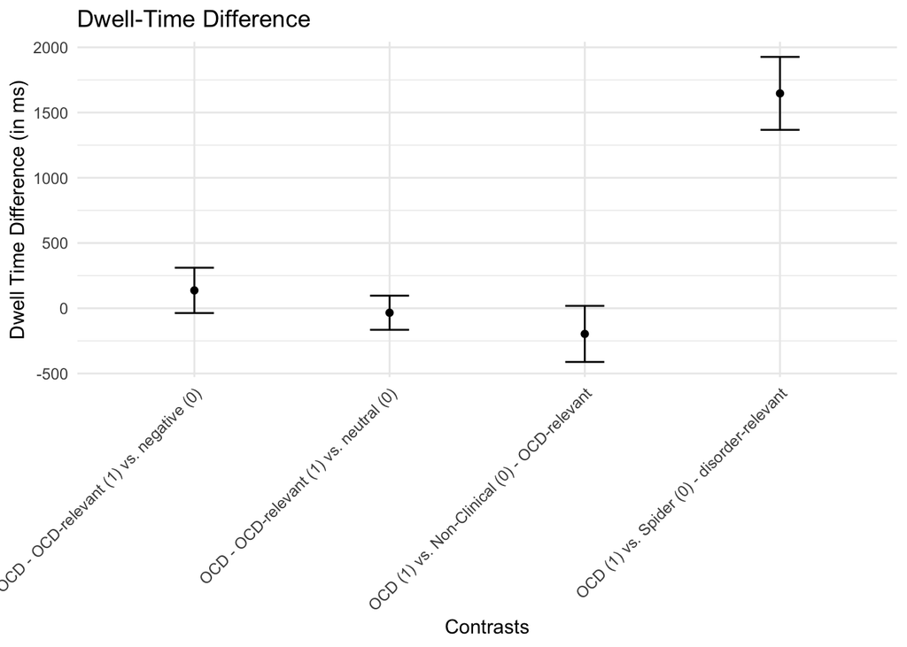

```r
# H1
h1_contrasts$names <- c("OCD - OCD-relevant (1) vs. neutral (0)", "OCD - OCD-relevant (1) vs. negative (0)", "OCD (1) vs. Non-Clinical (0) - OCD-relevant", "OCD (1) vs. Spider (0) - disorder-relevant")

h1_plot <- ggplot(h1_contrasts, aes(x = names, y = Estimate)) +
  geom_point() +
  geom_errorbar(aes(ymin = lower, ymax = upper), width = 0.2) +
  labs(title = "Dwell-Time Difference", y = "Dwell Time Difference (in ms)", x = "Contrasts") +
  theme(axis.text.x = element_text(angle = 45)) +
  theme_minimal() +
  theme(axis.text.x = element_text(angle = 45, hjust = 1)) # Apply 45-degree rotation to x-axis labels

h1_plot
```

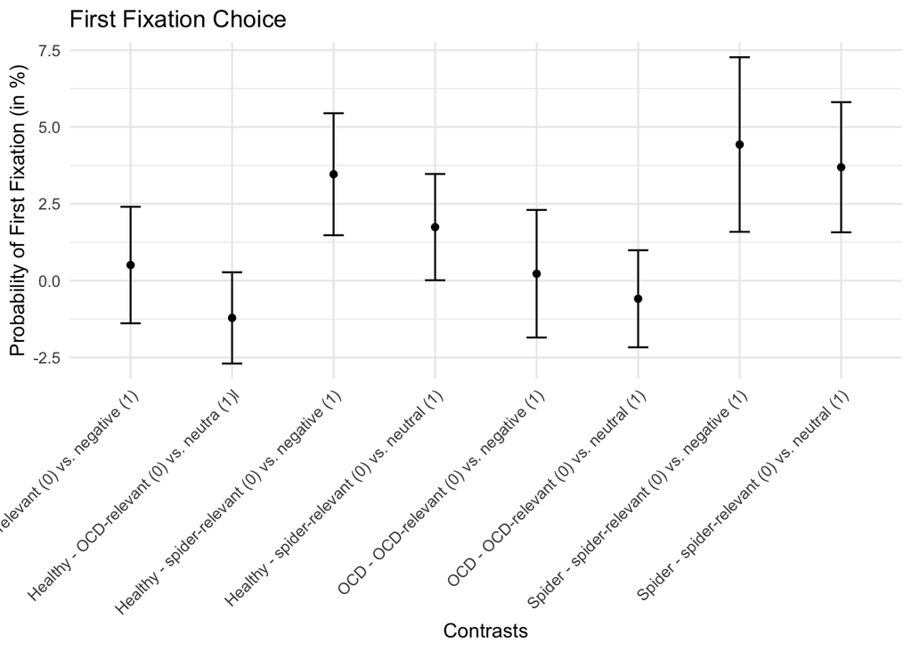

```r
# H2a
h2a_contrasts$names <- c("OCD - OCD-relevant (0) vs. neutral (1)", "OCD - OCD-relevant (0) vs. negative (1)",
                            "Spider - spider-relevant (0) vs. neutral (1)", "Spider - spider-relevant (0) vs. negative (1)",
                            "Healthy - OCD-relevant (0) vs. neutra (1)l", "Healthy - OCD-relevant (0) vs. negative (1)",
                            "Healthy - spider-relevant (0) vs. neutral (1)", "Healthy - spider-relevant (0) vs. negative (1)")

h2a_contrasts <- h2a_contrasts %>%
  dplyr::mutate(Estimate_perc = Estimate*100)
h2a_plot <- ggplot(h2a_contrasts, aes(x = names, y = Estimate_perc)) +
  geom_point() +
  geom_errorbar(aes(ymin = lower*100, ymax = upper*100), width = 0.2) +
  labs(title = "First Fixation Choice", y = "Probability of First Fixation (in %)", x = "Contrasts") +
  theme_minimal() +
  theme(axis.text.x = element_text(angle = 45, hjust = 1))
h2a_plot
```

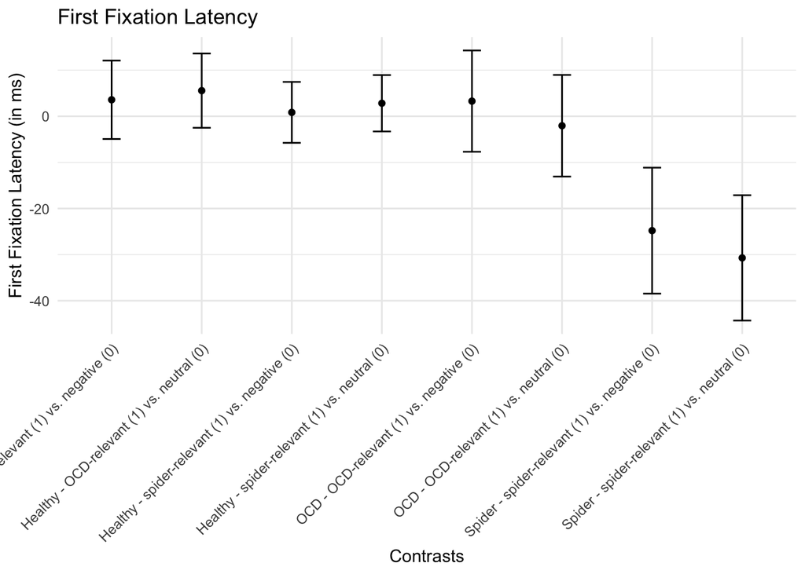

```r
# H2b
h2b_contrasts$names <- c("OCD - OCD-relevant (1) vs. neutral (0)", "OCD - OCD-relevant (1) vs. negative (0)",
                            "Spider - spider-relevant (1) vs. neutral (0)", "Spider - spider-relevant (1) vs. negative (0)",
                            "Healthy - OCD-relevant (1) vs. neutral (0)", "Healthy - OCD-relevant (1) vs. negative (0)",
                            "Healthy - spider-relevant (1) vs. neutral (0)", "Healthy - spider-relevant (1) vs. negative (0)")

h2b_plot <- ggplot(h2b_contrasts, aes(x = names, y = Estimate)) +
  geom_point() +
  geom_errorbar(aes(ymin = lower, ymax = upper), width = 0.2) +
  labs(title = "First Fixation Latency", y = "First Fixation Latency (in ms)", x = "Contrasts") +
  theme_minimal() +
  theme(axis.text.x = element_text(angle = 45, hjust = 1))

h2b_plot
```

# Testing Convergence Issue of H2b With Julia

```julia
# Define coding
c_rt = Dict(:group=>DummyCoding(;base="healthy"),:looked_right=>EffectsCoding(),:looked_at=>DummyCoding(;base="neutral"))
```

```
## Dict{Symbol, StatsModels.AbstractContrasts} with 3 entries:
##   :looked_at    => DummyCoding("neutral", nothing)
##   :group        => DummyCoding("healthy", nothing)
##   :looked_right => EffectsCoding(nothing, nothing)
```

```julia
# Define model

h2b_fm_excl_triplet_item = @formula(rt ~ group*looked_at + looked_right*group +
              (1 + looked_at + looked_right | participant))
```

```
## FormulaTerm
## Response:
##   rt(unknown)
## Predictors:
##   group(unknown)
##   looked_at(unknown)
##   looked_right(unknown)
##   group(unknown) & looked_at(unknown)
##   looked_right(unknown) & group(unknown)
##   (looked_at,looked_right,participant)->(1 + looked_at + looked_right) | participant
```

```julia
# Calculate model
h2b_fm_excl_triplet_item = fit(LinearMixedModel, h2b_fm_excl_triplet_item, jl_data_entrytime; contrasts=c_rt)
```

```
## Linear mixed model fit by maximum likelihood
##  rt ~ 1 + group + looked_at + looked_right + group & looked_at + looked_right & group + (1 + looked_at + looked_right | participant)
##     logLik     -2 logLik       AIC         AICc          BIC
##  -157159.3033  314318.6066  314380.6066  314380.6842  314633.2771
##
## Variance components:
##                   Column         Variance   Std.Dev.   Corr.
## participant (Intercept)          6220.35747  78.86924
##             looked_at: neg        284.07758  16.85460 -0.47
##             looked_at: ocd          8.64513   2.94026 -0.34 +0.16
##             looked_at: pho        191.67927  13.84483 -0.74 +0.89 +0.52
##             looked_right: true   1975.03723  44.44139 +0.40 -0.01 +0.70 +0.09
## Residual                        11973.65242 109.42419
##  Number of obs: 25608; levels of grouping factors: 165
##
##   Fixed-effects parameters:
## ───────────────────────────────────────────────────────────────────────────
##                                          Coef.  Std. Error      z  Pr(>|z|)
## ───────────────────────────────────────────────────────────────────────────
## (Intercept)                         351.855       10.1543   34.65    <1e-99
## group: ocd                           10.6375      15.2425    0.70    0.4853
## group: spider                        54.7975      15.258     3.59    0.0003
## looked_at: neg                        2.09464      3.61108   0.58    0.5619
## looked_at: ocd                        5.32332      4.02748   1.32    0.1863
## looked_at: pho                        3.6432       3.47868   1.05    0.2950
## looked_right: true                   12.1432       5.89319   2.06    0.0393
## group: ocd & looked_at: neg          -7.39244      5.17719  -1.43    0.1533
## group: spider & looked_at: neg      -10.0979       5.19936  -1.94    0.0521
## group: ocd & looked_at: ocd          -7.85355      6.84523  -1.15    0.2513
## group: spider & looked_at: ocd      -10.8814       5.99442  -1.82    0.0695
## group: ocd & looked_at: pho          -8.7177       5.16029  -1.69    0.0911
## group: spider & looked_at: pho      -26.7303       7.80435  -3.43    0.0006
## looked_right: true & group: ocd       0.355824     8.85298   0.04    0.9679
## looked_right: true & group: spider    1.56255      8.79479   0.18    0.8590
## ───────────────────────────────────────────────────────────────────────────
```

```julia
println(h2b_fm_excl_triplet_item)
```

```
## Linear mixed model fit by maximum likelihood
##  rt ~ 1 + group + looked_at + looked_right + group & looked_at + looked_right & group + (1 + looked_at + looked_right | participant)
##     logLik     -2 logLik       AIC         AICc          BIC
##  -157159.3033  314318.6066  314380.6066  314380.6842  314633.2771
##
## Variance components:
##                   Column         Variance   Std.Dev.   Corr.
## participant (Intercept)          6220.35747  78.86924
##             looked_at: neg        284.07758  16.85460 -0.47
##             looked_at: ocd          8.64513   2.94026 -0.34 +0.16
##             looked_at: pho        191.67927  13.84483 -0.74 +0.89 +0.52
##             looked_right: true   1975.03723  44.44139 +0.40 -0.01 +0.70 +0.09
## Residual                        11973.65242 109.42419
##  Number of obs: 25608; levels of grouping factors: 165
##
##   Fixed-effects parameters:
## ───────────────────────────────────────────────────────────────────────────
##                                          Coef.  Std. Error      z  Pr(>|z|)
## ───────────────────────────────────────────────────────────────────────────
## (Intercept)                         351.855       10.1543   34.65    <1e-99
## group: ocd                           10.6375      15.2425    0.70    0.4853
## group: spider                        54.7975      15.258     3.59    0.0003
## looked_at: neg                        2.09464      3.61108   0.58    0.5619
## looked_at: ocd                        5.32332      4.02748   1.32    0.1863
## looked_at: pho                        3.6432       3.47868   1.05    0.2950
## looked_right: true                   12.1432       5.89319   2.06    0.0393
## group: ocd & looked_at: neg          -7.39244      5.17719  -1.43    0.1533
## group: spider & looked_at: neg      -10.0979       5.19936  -1.94    0.0521
## group: ocd & looked_at: ocd          -7.85355      6.84523  -1.15    0.2513
## group: spider & looked_at: ocd      -10.8814       5.99442  -1.82    0.0695
## group: ocd & looked_at: pho          -8.7177       5.16029  -1.69    0.0911
## group: spider & looked_at: pho      -26.7303       7.80435  -3.43    0.0006
## looked_right: true & group: ocd       0.355824     8.85298   0.04    0.9679
## looked_right: true & group: spider    1.56255      8.79479   0.18    0.8590
## ───────────────────────────────────────────────────────────────────────────
```

```julia
println(h2b_fm_excl_triplet_item.optsum)
```

```
## Initial parameter vector: [1.0, 0.0, 0.0, 0.0, 0.0, 1.0, 0.0, 0.0, 0.0, 1.0, 0.0, 0.0, 1.0, 0.0, 1.0]
## Initial objective value:  315428.11760418775
##
## Optimizer (from NLopt):   LN_BOBYQA
## Lower bounds:             [0.0, -Inf, -Inf, -Inf, -Inf, 0.0, -Inf, -Inf, -Inf, 0.0, -Inf, -Inf, 0.0, -Inf, 0.0]
## ftol_rel:                 1.0e-12
## ftol_abs:                 1.0e-8
## xtol_rel:                 0.0
## xtol_abs:                 [1.0e-10, 1.0e-10, 1.0e-10, 1.0e-10, 1.0e-10, 1.0e-10, 1.0e-10, 1.0e-10, 1.0e-10, 1.0e-10, 1.0e-10, 1.0e-10, 1.0e-10, 1.0e-10, 1.0e-10]
## initial_step:             [0.75, 1.0, 1.0, 1.0, 1.0, 0.75, 1.0, 1.0, 1.0, 0.75, 1.0, 1.0, 0.75, 1.0, 0.75]
## maxfeval:                 -1
## maxtime:                  -1.0
##
## Function evaluations:     523
## Final parameter vector:   [0.7207660936520368, -0.07283598615038867, -0.009061490006590582, -0.09309875134325371, 0.16330953172197143, 0.1357208250117913, -0.0001354704961281171, 0.0776088024792393, 0.08309181777037081, 0.025295922429480262, 0.036282807119387576, 0.36231452924252605, 0.0012147659…
## Final objective value:    314318.6066375161
## Return code:              FTOL_REACHED
```

```julia
Pkg.add("DataFrames")
Pkg.add("PrettyTables")
Pkg.add("Distributions")
using DataFrames, MixedModels, LinearAlgebra, PrettyTables

# Extract fixed effects and covariance matrix
fixed_effects = coefnames(h2b_fm_excl_triplet_item)         # Names of fixed effects
```

```
## 15-element Vector{String}:
##  "(Intercept)"
##  "group: ocd"
##  "group: spider"
##  "looked_at: neg"
##  "looked_at: ocd"
##  "looked_at: pho"
##  "looked_right: true"
##  "group: ocd & looked_at: neg"
##  "group: spider & looked_at: neg"
##  "group: ocd & looked_at: ocd"
##  "group: spider & looked_at: ocd"
##  "group: ocd & looked_at: pho"
##  "group: spider & looked_at: pho"
##  "looked_right: true & group: ocd"
##  "looked_right: true & group: spider"
```

```julia
coefficients = fixef(h2b_fm_excl_triplet_item)             # Fixed effect estimates
```

```
## 15-element Vector{Float64}:
##  351.85515350492085
##   10.637487813541556
##   54.7975385163059
##    2.0946447901839598
##    5.3233170547230655
##    3.643197302417285
##   12.143152608298944
##   -7.392444844955832
##  -10.097879716096509
##   -7.853546072766796
##  -10.881405105858018
##   -8.717698311664652
##  -26.730335297088054
##    0.3558236916761604
##    1.5625473558068723
```

```julia
covariance_matrix = vcov(h2b_fm_excl_triplet_item)         # Covariance matrix of fixed effects
```

```
## 15×15 Matrix{Float64}:
##   103.11     -103.11     -103.11     …  -23.3022      -23.3022
##  -103.11      232.334     103.11         52.5779       23.3022
##  -103.11      103.11      232.808        23.3022       52.6597
##   -13.3758     13.3758     13.3758       -0.00195436   -0.00195436
##    -4.73626     4.73626     4.73626      -1.49703      -1.49703
##   -16.0276     16.0276     16.0276   …   -0.826472     -0.826472
##    23.3022    -23.3022    -23.3022      -34.7297      -34.7297
##    13.3758    -29.7457    -13.3758        0.0920422     0.00195436
##    13.3758    -13.3758    -29.9511        0.00195436    0.433769
##     4.73626   -10.7599     -4.73626       2.78147       1.49703
##     4.73626    -4.73626   -10.3184   …    1.49703       3.55174
##    16.0276    -35.744     -16.0276        1.73086       0.826472
##    16.0276    -16.0276    -36.3371        0.826472      0.61361
##   -23.3022     52.5779     23.3022       78.3752       34.7297
##   -23.3022     23.3022     52.6597       34.7297       77.3484
```

```julia
# Define contrasts for directional hypotheses
contrast_matrix_directional = [
    Dict("looked_at: ocd" => 1, "group: ocd & looked_at: ocd" => 1),  # OCD-relevant vs Neutral (OCD Group)
    Dict("looked_at: ocd" => 1, "group: ocd & looked_at: ocd" => 1,
         "looked_at: neg" => -1, "group: ocd & looked_at: neg" => -1),  # OCD-relevant vs Negative (OCD Group)
    Dict("looked_at: pho" => 1, "group: spider & looked_at: pho" => 1),  # Spider-relevant vs Neutral (Spider Group)
    Dict("looked_at: pho" => 1, "group: spider & looked_at: pho" => 1,
         "looked_at: neg" => -1, "group: spider & looked_at: neg" => -1)  # Spider-relevant vs Negative (Spider Group)
]
```

```
## 4-element Vector{Dict{String, Int64}}:
##  Dict("group: ocd & looked_at: ocd" => 1, "looked_at: ocd" => 1)
##  Dict("looked_at: neg" => -1, "group: ocd & looked_at: ocd" => 1, "looked_at: ocd" => 1, "group: ocd & looked_at: neg" => -1)
##  Dict("group: spider & looked_at: pho" => 1, "looked_at: pho" => 1)
##  Dict("group: spider & looked_at: pho" => 1, "looked_at: neg" => -1, "group: spider & looked_at: neg" => -1, "looked_at: pho" => 1)
```

```julia
# Compute contrasts for directional hypotheses
contrast_results_directional = []
```

```
## Any[]
```

```julia
for contrast in contrast_matrix_directional
    contrast_vector = zeros(length(fixed_effects))  # Initialize contrast vector
    for (name, weight) in contrast
        index = findfirst(==(name), fixed_effects)  # Find index of name in fixed_effects
        if index !== nothing
            contrast_vector[index] = weight
        else
            println("Warning: Term not found in fixed effects: ", name)
        end
    end

    # Calculate contrast value and standard error
    contrast_value = dot(coefficients, contrast_vector)
    contrast_variance = transpose(contrast_vector) * covariance_matrix * contrast_vector
    contrast_se = sqrt(contrast_variance)

    # Store results
    push!(contrast_results_directional, (contrast_value, contrast_se))
end

# Define contrasts for equality hypotheses
contrast_matrix_equality = [
    Dict("looked_at: ocd" => 1),  # OCD-relevant = Neutral (Healthy Group)
    Dict("looked_at: ocd" => 1, "looked_at: neg" => -1),  # OCD-relevant = Negative (Healthy Group)
    Dict("looked_at: pho" => 1),  # Spider-relevant = Neutral (Healthy Group)
    Dict("looked_at: pho" => 1, "looked_at: neg" => -1)  # Spider-relevant = Negative (Healthy Group)
]
```

```
## 4-element Vector{Dict{String, Int64}}:
##  Dict("looked_at: ocd" => 1)
##  Dict("looked_at: neg" => -1, "looked_at: ocd" => 1)
##  Dict("looked_at: pho" => 1)
##  Dict("looked_at: neg" => -1, "looked_at: pho" => 1)
```

```julia
# Compute contrasts for equality hypotheses
contrast_results_equality = []
```

```
## Any[]
```

```julia
for contrast in contrast_matrix_equality
    contrast_vector = zeros(length(fixed_effects))  # Initialize contrast vector
    for (name, weight) in contrast
        index = findfirst(==(name), fixed_effects)  # Find index of name in fixed_effects
        if index !== nothing
            contrast_vector[index] = weight
        else
            println("Warning: Term not found in fixed effects: ", name)
        end
    end

    # Calculate contrast value and standard error
    contrast_value = dot(coefficients, contrast_vector)
    contrast_variance = transpose(contrast_vector) * covariance_matrix * contrast_vector
    contrast_se = sqrt(contrast_variance)

    # Store results
    push!(contrast_results_equality, (contrast_value, contrast_se))
end

# Create DataFrames for results
using Distributions
contrast_names_directional = ["OCD-relevant vs Neutral (OCD Group)",
                              "OCD-relevant vs Negative (OCD Group)",
                              "Spider-relevant vs Neutral (Spider Group)",
                              "Spider-relevant vs Negative (Spider Group)"]
```

```
## 4-element Vector{String}:
##  "OCD-relevant vs Neutral (OCD Group)"
##  "OCD-relevant vs Negative (OCD Group)"
##  "Spider-relevant vs Neutral (Spider Group)"
##  "Spider-relevant vs Negative (Spider Group)"
```

```julia
contrast_names_equality = ["OCD-relevant = Neutral (Healthy Group)",
                           "OCD-relevant = Negative (Healthy Group)",
                           "Spider-relevant = Neutral (Healthy Group)",
                           "Spider-relevant = Negative (Healthy Group)"]
```

```
## 4-element Vector{String}:
##  "OCD-relevant = Neutral (Healthy Group)"
##  "OCD-relevant = Negative (Healthy Group)"
##  "Spider-relevant = Neutral (Healthy Group)"
##  "Spider-relevant = Negative (Healthy Group)"
```

```julia
h2b_dir_results_df = DataFrame(
    Contrast = contrast_names_directional,
    Estimate = [result[1] for result in contrast_results_directional],
    SE = [result[2] for result in contrast_results_directional],
    t_value = [result[1] / result[2] for result in contrast_results_directional],
    p_value = [2 * (1 - cdf(Normal(0, 1), abs(result[1] / result[2]))) for result in contrast_results_directional]
)
```

```
## 4×5 DataFrame
##  Row │ Contrast                           Estimate   SE       t_value    p_val ⋯
##      │ String                             Float64    Float64  Float64    Float ⋯
## ─────┼──────────────────────────────────────────────────────────────────────────
##    1 │ OCD-relevant vs Neutral (OCD Gro…   -2.53023  5.53502  -0.457131  0.647 ⋯
##    2 │ OCD-relevant vs Negative (OCD Gr…    2.76757  5.97282   0.463361  0.643
##    3 │ Spider-relevant vs Neutral (Spid…  -23.0871   6.98617  -3.30469   0.000
##    4 │ Spider-relevant vs Negative (Spi…  -15.0839   6.85278  -2.20114   0.027
##                                                                 1 column omitted
```

```julia
h2b_eq_results_df = DataFrame(
    Contrast = contrast_names_equality,
    Estimate = [result[1] for result in contrast_results_equality],
    SE = [result[2] for result in contrast_results_equality],
    t_value = [result[1] / result[2] for result in contrast_results_equality],
    p_value = [2 * (1 - cdf(Normal(0, 1), abs(result[1] / result[2]))) for result in contrast_results_equality]
)
```

```
## 4×5 DataFrame
##  Row │ Contrast                           Estimate  SE       t_value   p_value ⋯
##      │ String                             Float64   Float64  Float64   Float64 ⋯
## ─────┼──────────────────────────────────────────────────────────────────────────
##    1 │ OCD-relevant = Neutral (Healthy …   5.32332  4.02748  1.32175   0.18625 ⋯
##    2 │ OCD-relevant = Negative (Healthy…   3.22867  4.72234  0.683701  0.49416
##    3 │ Spider-relevant = Neutral (Healt…   3.6432   3.47868  1.04729   0.29496
##    4 │ Spider-relevant = Negative (Heal…   1.54855  3.42904  0.451599  0.65155
##                                                                 1 column omitted
```

```julia
Pkg.add("CSV")
using CSV
# Round values for better presentation
for col in [:Estimate, :SE, :t_value, :p_value]
    h2b_dir_results_df[!, col] = round.(h2b_dir_results_df[!, col], digits=3)
    h2b_eq_results_df[!, col] = round.(h2b_eq_results_df[!, col], digits=3)
end

# Print the tables
pretty_table(h2b_dir_results_df)
```

```
## ┌────────────────────────────────────────────┬──────────┬─────────┬─────────┬─────────┐
## │                                   Contrast │ Estimate │      SE │ t_value │ p_value │
## │                                     String │  Float64 │ Float64 │ Float64 │ Float64 │
## ├────────────────────────────────────────────┼──────────┼─────────┼─────────┼─────────┤
## │        OCD-relevant vs Neutral (OCD Group) │    -2.53 │   5.535 │  -0.457 │   0.648 │
## │       OCD-relevant vs Negative (OCD Group) │    2.768 │   5.973 │   0.463 │   0.643 │
## │  Spider-relevant vs Neutral (Spider Group) │  -23.087 │   6.986 │  -3.305 │   0.001 │
## │ Spider-relevant vs Negative (Spider Group) │  -15.084 │   6.853 │  -2.201 │   0.028 │
## └────────────────────────────────────────────┴──────────┴─────────┴─────────┴─────────┘
```

```julia
pretty_table(h2b_eq_results_df)
```

```
## ┌────────────────────────────────────────────┬──────────┬─────────┬─────────┬─────────┐
## │                                   Contrast │ Estimate │      SE │ t_value │ p_value │
## │                                     String │  Float64 │ Float64 │ Float64 │ Float64 │
## ├────────────────────────────────────────────┼──────────┼─────────┼─────────┼─────────┤
## │     OCD-relevant = Neutral (Healthy Group) │    5.323 │   4.027 │   1.322 │   0.186 │
## │    OCD-relevant = Negative (Healthy Group) │    3.229 │   4.722 │   0.684 │   0.494 │
## │  Spider-relevant = Neutral (Healthy Group) │    3.643 │   3.479 │   1.047 │   0.295 │
## │ Spider-relevant = Negative (Healthy Group) │    1.549 │   3.429 │   0.452 │   0.652 │
## └────────────────────────────────────────────┴──────────┴─────────┴─────────┴─────────┘
```

```julia
# Save the results to CSV
CSV.write("/Volumes/109-psy-kp-study/044_EYE/06_Results/02_Hauptstudie/TryOut/Models_and_Contrasts_with_Julia/h2b_directional_contrasts.csv", h2b_dir_results_df)
```

```
## "/Volumes/109-psy-kp-study/044_EYE/06_Results/02_Hauptstudie/TryOut/Models_and_Contrasts_with_Julia/h2b_directional_contrasts.csv"
```

```julia
CSV.write("/Volumes/109-psy-kp-study/044_EYE/06_Results/02_Hauptstudie/TryOut/Models_and_Contrasts_with_Julia/h2b_equality_contrasts.csv", h2b_eq_results_df)
```

```
## "/Volumes/109-psy-kp-study/044_EYE/06_Results/02_Hauptstudie/TryOut/Models_and_Contrasts_with_Julia/h2b_equality_contrasts.csv"
```